# Raster and Vector Data Cubes Across Spatial Data Science Languages

Introduction to vector data cubes in Python, R and Julia

Authors

Affiliations

Yomna Eid

University of Münster

Mohammad Alasawedah

University of Münster

Abhishek Singh

Eurac Research

Felix Cremer

Max-Planck Institute for Biogeochemistry

Lazaro Alonso

Max-Planck Institute for Biogeochemistry

Published

June 23, 2025

# 1 Introdution to Raster and Vector Data Cubes

In this notebook, we convert a raster data cube covering a large spatial extent to a vector data cube containing only the spatial areas of interest. Observe how geospatial features, or data associated with those features, change over time.

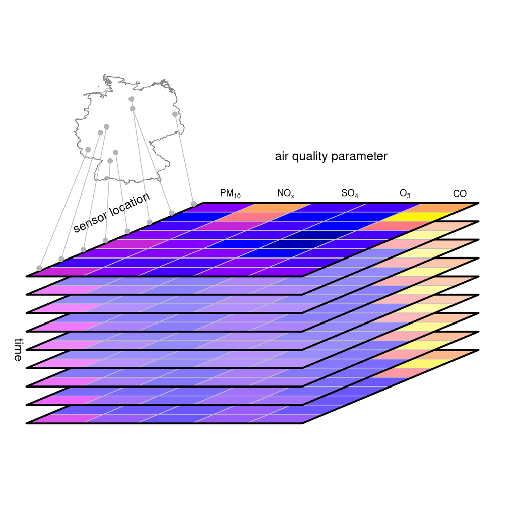

Start of Code

**R**

```r
# If the libraries are not available, install them
packages <- c("terra", "lubridate", "stars", "ggplot2", "caret", "ranger", "dplyr", "tidyr")
for (p in packages){
  if (!requireNamespace(p, quietly = TRUE)){
    install.packages(p, repos = "https://cran.uni-muenster.de/")
  }
}
lapply(packages, library, character.only = TRUE);
```

```
terra 1.8.54
```

[output not shown]

**Python**

```python
import os
import string
from glob import glob
import pandas as pd
import numpy as np
import zipfile
import xvec
import xarray as xr
import geopandas as gpd
import rasterio
import rioxarray as rio
import shapely.geometry
from shapely.geometry import Point
import folium
import leafmap.foliumap as leafmap
import matplotlib.pyplot as plt
import matplotlib.cm as cm
```

**Julia**

```julia
#Installation
using Pkg;
Pkg.activate("../Julia")
Pkg.add([
    "Glob",
    "Dates",
    "DataFrames",
    "Shapefile",
    "GeometryOps",
    "ArchGDAL",
    "GeoInterface",
    "Proj",
    "Statistics",
    "CairoMakie",
    "LibGEOS",
    "IntervalSets",
    "Tyler"
    ]
    )

#the bleeding edge devs (soon to be merge)
Pkg.add(url="https://github.com/rafaqz/DimensionalData.jl", rev="main")
Pkg.add(url="https://github.com/rafaqz/Rasters.jl", rev="as/vectordatacubes")

#loading
using Rasters
using Shapefile
using Proj
using Glob
using ZipFile
using DimensionalData
using Dates
using Statistics
using DataFrames
using CairoMakie
using Tyler
import ArchGDAL
import GeometryOps as GO
import GeoInterface as GI
import LibGEOS
using IntervalSets
```

**R**

First, we list all the LAI files and then we sort them.

```r
dir = r"(C:\Users\Yomna Eid\Documents\1b. PhD\DataCubes_Tutorial)" #|> setwd()

lai_files <- list.files(paste0(dir,"/lai_cropped/"), pattern = "\\.tif$", full.names = TRUE) |> sort()
```

**Python**

```python
# Path to data zip file
#zip_path = "C:\\Users\\Yomna Eid\\Documents\\1b. PhD\\DataCubes_Tutorial\\Data.zip"

# Folder to extract to
#extract_to = "Data/"

# Unzipping
#with zipfile.ZipFile(zip_path, 'r') as zip_ref:
#    zip_ref.extractall(extract_to)

lai_files = glob("C:/Users/Yomna Eid/Documents/1b. PhD/DataCubes_Tutorial/lai_cropped/*.tif")
```

**Julia**

```julia
#define functions to read the data + read dates from the file name
function read_files(path)
    ras_files = glob("*.tif", path)
    ras_dates = get_dates.(ras_files)
    ras = Raster.(ras_files, lazy=true, name=:data)
    return cat(ras..., dims=Ti(ras_dates))
end
```

```
read_files (generic function with 1 method)
```

**R**

```r
file_names <- basename(lai_files)
timestamps_str <- substr(file_names, nchar(file_names) - 18, nchar(file_names) - 4)
timestamps <- ymd_hms(timestamps_str)
```

**Python**

```python
basename = []
for x in lai_files:
    name = os.path.basename(x)
    name = pd.to_datetime(name[-19:-4])
    basename.append(name)
```

**Julia**

```julia
function get_dates(x)
    return DateTime(split(x, r"[_.]")[end-1], "yyyymmddTHHMMSS")
end
```

```
get_dates (generic function with 1 method)
```

**R**

Read the rasters into a list and stack them

```r
#Here we stack them into a SpatRaster
rasters <- lapply(lai_files, rast)

lai_stack <- rast(rasters)

# And we convert it into a stars object for time dimension support
lai_stars <- st_as_stars(lai_stack)
```

**Python**

```python
time = xr.Variable('time', basename)
lai_da = xr.concat([rio.open_rasterio(f) for f in lai_files], dim=time)
```

**Julia**

```julia
lai_ds = read_files("C:/Users/Yomna Eid/Documents/1b. PhD/DataCubes_Tutorial/lai_cropped/")
```

```
┌ 881×832×77 Raster{Float32, 3} data ┐
├────────────────────────────────────┴─────────────────────────────────── dims ┐
  ↓ X Projected{Float64} 698940.0:10.0:707740.0 ForwardOrdered Regular Intervals{Start},
  → Y Projected{Float64} 5.1811e6:-10.0:5.17279e6 ReverseOrdered Regular Intervals{Start},
  ↗ Ti Sampled{DateTime} [DateTime("2023-04-01T10:15:59"), …, DateTime("2023-10-30T10:11:41")] ForwardOrdered Irregular Points
├──────────────────────────────────────────────────────────────────── metadata ┤
  Metadata{Rasters.GDALsource} of Dict{String, Any} with 1 entry:
  "filepath" => "C:/Users/Yomna Eid/Documents/1b. PhD/DataCubes_Tutorial/lai_cr…
├────────────────────────────────────────────────────────────────────── raster ┤
  extent: Extent(X = (698940.0, 707750.0), Y = (5.17279e6, 5.18111e6), Ti = (DateTime("2023-04-01T10:15:59"), DateTime("2023-10-30T10:11:41")))
  crs: PROJCS["WGS 84 / UTM zone 32N",GEOGCS["WGS 84",DATUM["WGS_1984",SPHE...
└──────────────────────────────────────────────────────────────────────────────┘
```

**R**

```r
lai_stars <- st_set_dimensions(lai_stars, 3, values = timestamps, names = "time")
```

**Python**

```python
time = xr.Variable('time', basename)
lai_da = lai_da.sortby("time")
```

**Julia**

**R**

```r
names(lai_stars) <- "lai"
```

**Python**

```python
lai_ds = lai_da.to_dataset(dim="band").rename_vars({1:"lai"})
```

**Julia**

**R**

To plot one time stamp with ggplot2, we convert the stars object into a data frame

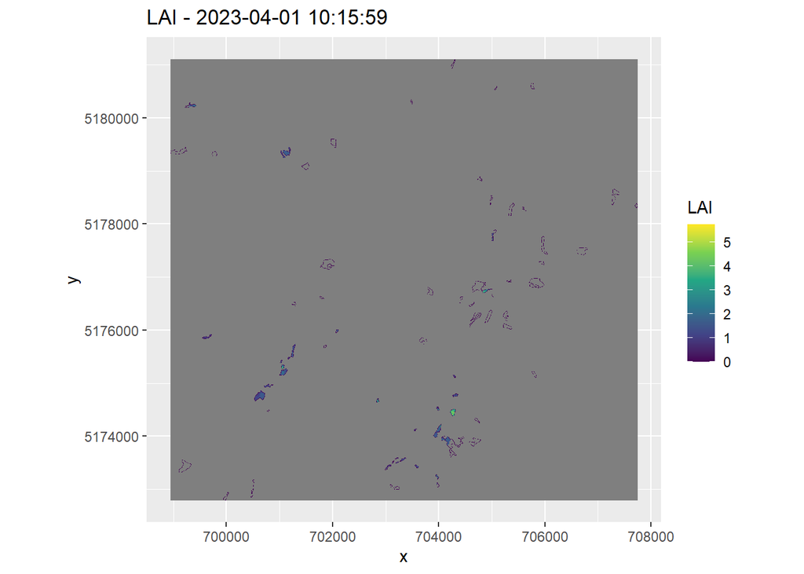

```r
lai_df <- as.data.frame(lai_stars[,,,1], xy = TRUE)

ggplot(lai_df, aes(x = x, y = y, fill = lai)) +
  geom_raster() +
  scale_fill_viridis_c() +
  coord_equal() +
  labs(title = paste("LAI -", format(st_get_dimension_values(lai_stars, "time")[1])),
       fill = "LAI")
```

**Python**

```python
# Plot LAI
ax = lai_ds["lai"].isel(time=0).plot()
ax = plt.gca()

ax.set_title("Leaf Area Index (LAI)")
plt.xticks(rotation=45)
```

```
(array([698000., 699000., 700000., 701000., 702000., 703000., 704000.,
       705000., 706000., 707000., 708000.]), [Text(698000.0, 0, '698000'), Text(699000.0, 0, '699000'), Text(700000.0, 0, '700000'), Text(701000.0, 0, '701000'), Text(702000.0, 0, '702000'), Text(703000.0, 0, '703000'), Text(704000.0, 0, '704000'), Text(705000.0, 0, '705000'), Text(706000.0, 0, '706…
```

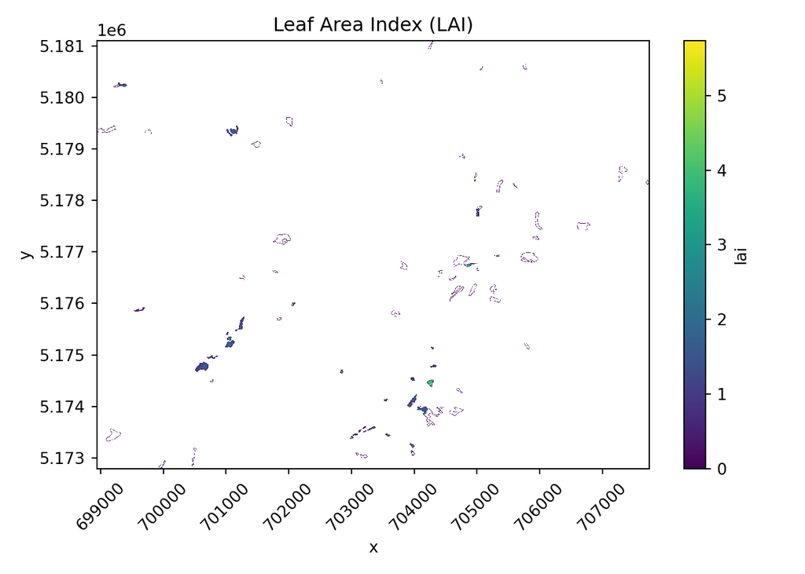

```python
plt.tight_layout()
plt.show()
```

**Julia**

```julia
set_theme!(theme_light(); size = (600, 350), fontsize=12.5)
plot(lai_ds[Ti=1])

# bonus
fig = with_theme(theme_ggplot2(); size = (600,400)) do
    fig, ax, plt = plot(lai_ds[Ti=2];
        colormap=:gist_rainbow, #nan_color=:grey95 # ! be mindful with your colormap choices
        )
    Colorbar(fig[1,2], plt, label = "LAI")
    fig
end

#visit ColorSchemes.jl for more colormaps!
```

[output not shown]

**R**

```r
rtc_asc_files <- list.files(paste0(dir,"/rtc_asc_cropped"), pattern = "\\.tif$", full.names = TRUE) |> sort()
```

**Python**

```python
rtc_asc_files = glob("C:/Users/Yomna Eid/Documents/1b. PhD/DataCubes_Tutorial/rtc_asc_cropped/*.tif")
```

**Julia**

```julia
rtc_asc = read_files("C:/Users/Yomna Eid/Documents/1b. PhD/DataCubes_Tutorial/rtc_asc_cropped/");
```

**R**

```r
file_names <- basename(rtc_asc_files)
timestamps_str <- substr(file_names, nchar(file_names) - 11, nchar(file_names) - 4)
timestamps <- as.POSIXct(ymd(timestamps_str))
```

**Python**

```python
basename = []
for x in rtc_asc_files:
    name = os.path.basename(x)
    name = pd.to_datetime(name[-12:-4])
    basename.append(name)
```

**Julia**

**R**

Read stars object with 3 dimensions: x, y, bands

```r
stars_list <- lapply(rtc_asc_files, function(f) {
  rast_obj <- rast(f)
  st_as_stars(rast_obj)
})

# Combine/stack all stars objects along a new "time" dimension
rtc_asc_stars <- do.call(c, c(stars_list, along = "time"))
```

**Python**

```python
time = xr.Variable('time', basename)
rtc_asc = xr.concat([rio.open_rasterio(f) for f in rtc_asc_files], dim=time)
```

**Julia**

**R**

Add the parsed time dimension values & rename bands name, to create the raster data-cube

```r
rtc_asc_stars <- st_set_dimensions(rtc_asc_stars, 4, values = timestamps, names = "time")
rtc_asc_stars <- st_set_dimensions(rtc_asc_stars, 3, values = c("vv_asc", "vh_asc"), names = "band")
names(rtc_asc_stars) <- "backscatter"
```

**Python**

```python
rtc_asc = xr.concat([rio.open_rasterio(f) for f in rtc_asc_files], dim=time)
rtc_asc = rtc_asc.sortby("time")
rtc_asc = rtc_asc.to_dataset(dim="band").rename_vars({1:"asc_vv", 2:"asc_vh"})
```

**Julia**

**R**

**Python**

```python
# Plot Acending S1 VV band
ax = rtc_asc["asc_vv"].isel(time=0).plot()
ax = plt.gca()

ax.set_title("Acending S1 - VV band")
plt.xticks(rotation=45)
```

```
(array([698000., 699000., 700000., 701000., 702000., 703000., 704000.,
       705000., 706000., 707000., 708000.]), [Text(698000.0, 0, '698000'), Text(699000.0, 0, '699000'), Text(700000.0, 0, '700000'), Text(701000.0, 0, '701000'), Text(702000.0, 0, '702000'), Text(703000.0, 0, '703000'), Text(704000.0, 0, '704000'), Text(705000.0, 0, '705000'), Text(706000.0, 0, '706…
```

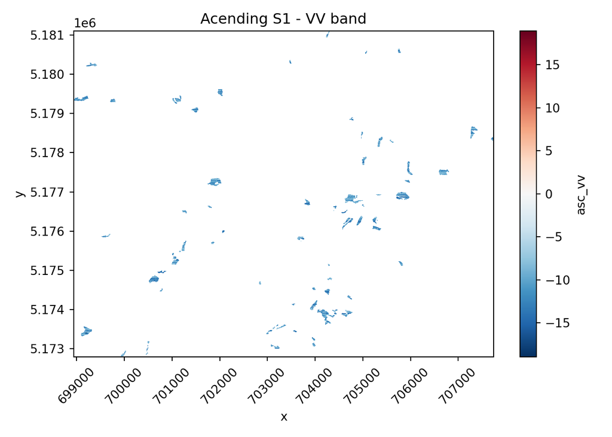

```python
plt.tight_layout()
plt.show()
```

**Julia**

```julia
plot(rtc_asc[Ti=1, Band=At("RTC_VV")])
plot(rtc_asc[Ti=1, Band=At("RTC_VH")])
```

[output not shown]

**R**

```r
vv <- rtc_asc_stars[, , , band = 1, drop = FALSE]
vh <- rtc_asc_stars[, , , band = 2, drop = FALSE]
rvi <- (4 * vv$backscatter) / (vv$backscatter + vh$backscatter)
rvi_stars <- st_as_stars(rvi)
names(rvi_stars) <- "asc_rvi"  # name the new variable
rvi_stars <- st_set_dimensions(rvi_stars, 4, values = timestamps, names = "time")
rvi_stars <- st_set_dimensions(rvi_stars, 3, values = "rvi_asc", names = "band")
rtc_asc_stars = c(rtc_asc_stars, rvi_stars, along= "band")
```

**Python**

```python
rtc_asc['asc_rvi'] = (4*rtc_asc['asc_vv']) / (rtc_asc['asc_vv'] + rtc_asc['asc_vh'])
```

**Julia**

```julia
rtc_asc_rvi =  @. 4 * rtc_asc[Band = At("RTC_VH")] / (rtc_asc[Band = At("RTC_VV")] + rtc_asc[Band = At("RTC_VH")]);
```

**R**

```r
VV_VH <- vv$backscatter / vh$backscatter
VV_VH_stars <- st_as_stars(VV_VH)
names(VV_VH_stars) <- "asc_VV_VH"  # name the new variable
VV_VH_stars <- st_set_dimensions(VV_VH_stars, 4, values = timestamps, names = "time")
VV_VH_stars <- st_set_dimensions(VV_VH_stars, 3, values = "ratio_asc", names = "band")
rtc_asc_stars = c(rtc_asc_stars, VV_VH_stars, along= "band")
```

**Python**

```python
rtc_asc['asc_vv/vh'] = rtc_asc['asc_vv'] / rtc_asc['asc_vh']
```

**Julia**

```julia
rtc_asc_ratio  =  @. rtc_asc[Band = At("RTC_VV")] / rtc_asc[Band = At("RTC_VH")];

# collect/rename previous Bands plus the new ones.
new_bands = Rasters.Band("asc_" .* [dims(rtc_asc, Rasters.Band)..., "VV/VH", "RVI"])
```

```
Band ["asc_RTC_VV", …, "asc_RVI"]
```

```julia
rtc_asc = cat(rtc_asc[Band=1], rtc_asc[Band=2], rtc_asc_ratio, rtc_asc_rvi; dims=new_bands)
```

```
┌ 881×832×65×4 Raster{Union{Missing, Float32}, 4} data ┐
├──────────────────────────────────────────────────────┴───────────────── dims ┐
  ↓ X Projected{Float64} 698935.421906009:10.0:707735.421906009 ForwardOrdered Regular Intervals{Start},
  → Y Projected{Float64} 5.181100855994971e6:-10.0:5.172790855994971e6 ReverseOrdered Regular Intervals{Start},
  ↗ Ti Sampled{DateTime} [DateTime("2023-03-05T00:00:00"), …, DateTime("2023-11-26T00:00:00")] ForwardOrdered Irregular Points,
  ⬔ Band Categorical{String} ["asc_RTC_VV", …, "asc_RVI"] Unordered
├──────────────────────────────────────────────────────────────────── metadata ┤
  Metadata{Rasters.GDALsource} of Dict{String, Any} with 1 entry:
  "filepath" => "C:/Users/Yomna Eid/Documents/1b. PhD/DataCubes_Tutorial/rtc_as…
├────────────────────────────────────────────────────────────────────── raster ┤
  missingval: missing
  extent: Extent(X = (698935.421906009, 707745.421906009), Y = (5.172790855994971e6, 5.181110855994971e6), Ti = (DateTime("2023-03-05T00:00:00"), DateTime("2023-11-26T00:00:00")), Band = (nothing, nothing))
  crs: PROJCS["WGS 84 / UTM zone 32N",GEOGCS["WGS 84",DATUM["WGS_1984",SPHE...
└──────────────────────────────────────────────────────────────────────────────┘
[:, :, 1, 1]
 ↓ →        5.1811e6  5.18109e6  5.18108e6  …  5.17281e6  5.1728e6  5.17279e6
 6.98935e5   missing   missing    missing       missing    missing   missing
 ⋮                                          ⋱  ⋮
 7.07735e5   missing   missing    missing       missing    missing   missing
```

**R**

```r
rtc_dsc_files <- list.files(paste0(dir,"/rtc_dsc_cropped"), pattern = "\\.tif$", full.names = TRUE) |> sort()
```

**Python**

```python
rtc_dsc_files = glob("C:/Users/Yomna Eid/Documents/1b. PhD/DataCubes_Tutorial/rtc_dsc_cropped/*.tif")
```

**Julia**

```julia
rtc_dsc = read_files("C:/Users/Yomna Eid/Documents/1b. PhD/DataCubes_Tutorial/rtc_dsc_cropped/");
```

**R**

```r
file_names <- basename(rtc_dsc_files)
timestamps_str <- substr(file_names, nchar(file_names) - 11, nchar(file_names) - 4)
timestamps <- as.POSIXct(ymd(timestamps_str))
#timestamps <- as.POSIXct(paste(timestamps_str, "12:00:00")) |hide-line
```

**Python**

```python
basename = []
for x in rtc_dsc_files:
    name = os.path.basename(x)
    name = pd.to_datetime(name[-12:-4])
    basename.append(name)
```

**Julia**

**R**

Read stars object with 3 dimensions: x, y, bands

```r
stars_list <- lapply(rtc_dsc_files, function(f) {
  rast_obj <- rast(f)
  st_as_stars(rast_obj)
})
# Combine all stars objects along a new "time" dimension
rtc_dsc_stars <- do.call(c, c(stars_list, along = "time"))
```

**Python**

```python
time = xr.Variable('time', basename)
rtc_dsc = xr.concat([rio.open_rasterio(f) for f in rtc_dsc_files], dim=time)
```

**Julia**

**R**

Add time dimension values and rename the variables

```r
rtc_dsc_stars <- st_set_dimensions(rtc_dsc_stars, 4, values = timestamps, names = "time")
rtc_dsc_stars <- st_set_dimensions(rtc_dsc_stars, 3, values = c("vv_dsc", "vh_dsc"), names = "band")
```

**Python**

```python
rtc_dsc = rtc_dsc.sortby("time")
```

**Julia**

**R**

Rename the variable

```r
dsc_stars <- st_set_dimensions(rtc_dsc_stars, 3, values = c("vv_dsc", "vh_dsc"), names = "band")
names(rtc_dsc_stars) <- "backscatter"
```

**Python**

```python
rtc_dsc = rtc_dsc.to_dataset(dim="band").rename_vars({1:"dsc_vv", 2:"dsc_vh"})
```

**Julia**

**R**

Rename the variable

**Python**

```python
# Plot Dcending S1 VV band
ax = rtc_dsc["dsc_vv"].isel(time=0).plot()
ax = plt.gca()

ax.set_title("Decending S1 - VV band")
plt.xticks(rotation=45)
```

```
(array([698000., 699000., 700000., 701000., 702000., 703000., 704000.,
       705000., 706000., 707000., 708000.]), [Text(698000.0, 0, '698000'), Text(699000.0, 0, '699000'), Text(700000.0, 0, '700000'), Text(701000.0, 0, '701000'), Text(702000.0, 0, '702000'), Text(703000.0, 0, '703000'), Text(704000.0, 0, '704000'), Text(705000.0, 0, '705000'), Text(706000.0, 0, '706…
```

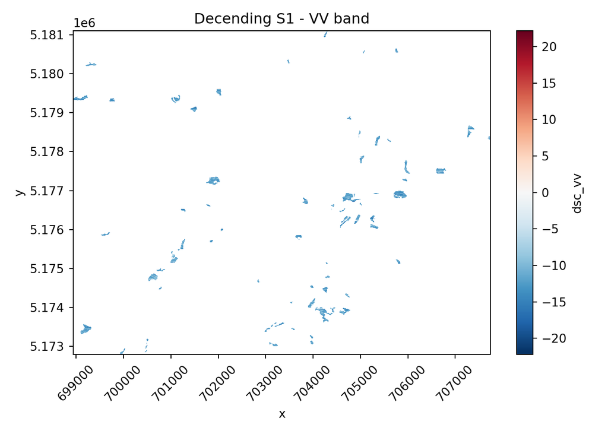

```python
plt.tight_layout()
plt.show()
```

**Julia**

```julia
plot(rtc_dsc[Ti=1, Band=At("RTC_VV")])
plot(rtc_dsc[Ti=1, Band=At("RTC_VH")])
```

[output not shown]

**R**

```r
vv <- rtc_dsc_stars[, , , band = 1, drop = FALSE]
vh <- rtc_dsc_stars[, , , band = 2, drop = FALSE]
rvi <- (4 * vv$backscatter) / (vv$backscatter + vh$backscatter)
rvi_stars <- st_as_stars(rvi)
names(rvi_stars) <- "dsc_rvi"  # name the new variable
rvi_stars <- st_set_dimensions(rvi_stars, 4, values = timestamps, names = "time")
rvi_stars <- st_set_dimensions(rvi_stars, 3, values = "rvi_dsc", names = "band")

rtc_dsc_stars = c(rtc_dsc_stars, rvi_stars, along= "band")
```

**Python**

```python
# Feature engineering for descending sentinel-1 data
rtc_dsc['dsc_rvi'] = (4*rtc_dsc['dsc_vv']) / (rtc_dsc['dsc_vv'] + rtc_dsc['dsc_vh'])
```

**Julia**

```julia
rtc_dsc_rvi =  @. 4 * rtc_dsc[Band = At("RTC_VH")] / (rtc_dsc[Band = At("RTC_VV")] + rtc_dsc[Band = At("RTC_VH")]);
```

**R**

2. VV/VH

```r
VV_VH <- vv$backscatter / vh$backscatter
VV_VH_stars <- st_as_stars(VV_VH)
names(VV_VH_stars) <- "asc_VV_VH"  # name the new variable
VV_VH_stars <- st_set_dimensions(VV_VH_stars, 4, values = timestamps, names = "time")
VV_VH_stars <- st_set_dimensions(VV_VH_stars, 3, values = "ratio_dsc", names = "band")
rtc_dsc_stars = c(rtc_dsc_stars, VV_VH_stars, along= "band")
```

**Python**

```python
rtc_dsc['dsc_vv/vh'] = rtc_dsc['dsc_vv'] / rtc_dsc['dsc_vh']
```

**Julia**

```julia
rtc_dsc_ratio  =  @. rtc_dsc[Band = At("RTC_VV")] / rtc_dsc[Band = At("RTC_VH")]
```

```
┌ 881×832×45 Raster{Union{Missing, Float32}, 3} ┐
├───────────────────────────────────────────────┴──────────────────────── dims ┐
  ↓ X Projected{Float64} 698935.421906009:10.0:707735.421906009 ForwardOrdered Regular Intervals{Start},
  → Y Projected{Float64} 5.181100855994971e6:-10.0:5.172790855994971e6 ReverseOrdered Regular Intervals{Start},
  ↗ Ti Sampled{DateTime} [DateTime("2023-03-04T00:00:00"), …, DateTime("2023-11-30T00:00:00")] ForwardOrdered Irregular Points
├──────────────────────────────────────────────────────────────────── metadata ┤
  Metadata{Rasters.GDALsource} of Dict{String, Any} with 1 entry:
  "filepath" => "C:/Users/Yomna Eid/Documents/1b. PhD/DataCubes_Tutorial/rtc_ds…
├────────────────────────────────────────────────────────────────────── raster ┤
  missingval: missing
  extent: Extent(X = (698935.421906009, 707745.421906009), Y = (5.172790855994971e6, 5.181110855994971e6), Ti = (DateTime("2023-03-04T00:00:00"), DateTime("2023-11-30T00:00:00")))
  crs: PROJCS["WGS 84 / UTM zone 32N",GEOGCS["WGS 84",DATUM["WGS_1984",SPHE...
└──────────────────────────────────────────────────────────────────────────────┘
[:, :, 1]
 ↓ →        5.1811e6  5.18109e6  5.18108e6  …  5.17281e6  5.1728e6  5.17279e6
 6.98935e5   missing   missing    missing       missing    missing   missing
 ⋮                                          ⋱  ⋮
 7.07725e5   missing   missing    missing   …   missing    missing   missing
 7.07735e5   missing   missing    missing       missing    missing   missing
```

```julia
# collect/rename previous Bands plus the new ones.
new_bands = Rasters.Band("dsc_" .* [dims(rtc_dsc, Rasters.Band)..., "VV/VH", "RVI"])
```

```
Band ["dsc_RTC_VV", …, "dsc_RVI"]
```

```julia
rtc_dsc = cat(rtc_dsc[Band=1], rtc_dsc[Band=2], rtc_dsc_ratio, rtc_dsc_rvi; dims=new_bands)
```

```
┌ 881×832×45×4 Raster{Union{Missing, Float32}, 4} data ┐
├──────────────────────────────────────────────────────┴───────────────── dims ┐
  ↓ X Projected{Float64} 698935.421906009:10.0:707735.421906009 ForwardOrdered Regular Intervals{Start},
  → Y Projected{Float64} 5.181100855994971e6:-10.0:5.172790855994971e6 ReverseOrdered Regular Intervals{Start},
  ↗ Ti Sampled{DateTime} [DateTime("2023-03-04T00:00:00"), …, DateTime("2023-11-30T00:00:00")] ForwardOrdered Irregular Points,
  ⬔ Band Categorical{String} ["dsc_RTC_VV", …, "dsc_RVI"] Unordered
├──────────────────────────────────────────────────────────────────── metadata ┤
  Metadata{Rasters.GDALsource} of Dict{String, Any} with 1 entry:
  "filepath" => "C:/Users/Yomna Eid/Documents/1b. PhD/DataCubes_Tutorial/rtc_ds…
├────────────────────────────────────────────────────────────────────── raster ┤
  missingval: missing
  extent: Extent(X = (698935.421906009, 707745.421906009), Y = (5.172790855994971e6, 5.181110855994971e6), Ti = (DateTime("2023-03-04T00:00:00"), DateTime("2023-11-30T00:00:00")), Band = (nothing, nothing))
  crs: PROJCS["WGS 84 / UTM zone 32N",GEOGCS["WGS 84",DATUM["WGS_1984",SPHE...
└──────────────────────────────────────────────────────────────────────────────┘
[:, :, 1, 1]
 ↓ →        5.1811e6  5.18109e6  5.18108e6  …  5.17281e6  5.1728e6  5.17279e6
 6.98935e5   missing   missing    missing       missing    missing   missing
 ⋮                                          ⋱  ⋮
 7.07735e5   missing   missing    missing       missing    missing   missing
```

# 2 Vector Data Cubes: Functions

#### 2.0.0.1 Zonal statistcs

Aggregate the values of raster data cubes for each farm, based on their geometries, to generate vector data cubes indexed by farm geometries instead of longitude and latitude.

**R**

```r
farms <- st_read("C:/Users/Yomna Eid/Documents/1b. PhD/DataCubes_Tutorial/quarto (R-kernel)/Data/shp/new_farms/farms.shp")
```

**Python**

```python
from shapely.geometry import box

farms = gpd.read_file("./Data/shp/farms.shp")
farms = farms.to_crs(epsg=4326)

print("There are ", farms.shape[0], " farms")
```

```
There are  66  farms
```

```python
farms.head(5)
```

```
        ID CODE  ...        Lat                                           geometry
0  1782222  AP2  ...  46.745927  POLYGON ((11.608 46.746, 11.608 46.746, 11.608...
1  2452708  AP2  ...  46.681033  MULTIPOLYGON (((11.621 46.68, 11.621 46.68, 11...
2  2753189  AP2  ...  46.704917  MULTIPOLYGON (((11.664 46.705, 11.664 46.705, ...
3  2286544  AP2  ...  46.713566  MULTIPOLYGON (((11.677 46.713, 11.677 46.713, ...
4  2881455  AP2  ...  46.707456  MULTIPOLYGON (((11.685 46.707, 11.685 46.707, ...

[5 rows x 13 columns]
```

```python
# Plot the farms over Sentinel-2 Data
farms['centroid'] = farms['geometry'].centroid
farms['Lon'] = farms['centroid'].x
farms['Lat'] = farms['centroid'].y

# Create a map and check the location of each cluster
center_lat, center_lon =  farms['Lat'].mean(), farms['Lon'].mean()

map_farms = leafmap.Map(location=[center_lat, center_lon], zoom_start=13)
map_farms.add_xyz_service("qms.EOX::Maps - Sentinel-2 cloudless")

style_function = lambda x: {'fillColor': '#3366cc', 'color': '#3366cc'}

folium.GeoJson(farms['geometry'], style_function=style_function).add_to(map_farms)
```

```
<folium.features.GeoJson object at 0x000001D77E7AFCE0>
```

```python
map_farms
```

[interactive chart not shown]

**Julia**

```julia
path_farms = "C:/Users/Yomna Eid/Documents/1b. PhD/DataCubes_Tutorial/shp/T_LAFIS_32632_buffered_classified_10percent.shp"
```

```
"C:/Users/Yomna Eid/Documents/1b. PhD/DataCubes_Tutorial/shp/T_LAFIS_32632_buffered_classified_10percent.shp"
```

```julia
farm_polygons = Shapefile.Table(joinpath("../data", path_farms))
```

```
Shapefile.Table{Union{Missing, Shapefile.Polygon}} with 3431 rows and the following 11 columns:

geometry, ID, CODE, DESCR_IT, DESCR_DE, elev, northness, slope, area, face, class
```

```julia
df = DataFrame(farm_polygons)
```

```
3431×11 DataFrame
  Row │ geometry             ID       CODE     DESCR_IT       DESCR_DE         ⋯
      │ Polygon?             Int64?   String?  String?        String?          ⋯
──────┼─────────────────────────────────────────────────────────────────────────
    1 │ Polygon(130 Points)  2773902  AP2      Prato stabile  Wiese (Dauerwies ⋯
    2 │ Polygon(88 Points)   1782222  AP2      Prato stabile  Wiese (Dauerwies
    3 │ Polygon(32 Points)   3052062  AP2      Prato stabile  Wiese (Dauerwies
    4 │ Polygon(83 Points)   3106782  AP2      Prato stabile  Wiese (Dauerwies
    5 │ Polygon(64 Points)   2763340  AP2      Prato stabile  Wiese (Dauerwies ⋯
    6 │ Polygon(92 Points)   2192067  AP2      Prato stabile  Wiese (Dauerwies
    7 │ Polygon(54 Points)   2356161  AP2      Prato stabile  Wiese (Dauerwies
    8 │ Polygon(264 Points)  3030843  AP2      Prato stabile  Wiese (Dauerwies
  ⋮   │          ⋮              ⋮        ⋮           ⋮                ⋮        ⋱
 3425 │ Polygon(81 Points)   2741635  AP2      Prato stabile  Wiese (Dauerwies ⋯
 3426 │ Polygon(63 Points)   2989404  AP2      Prato stabile  Wiese (Dauerwies
 3427 │ Polygon(24 Points)   3098873  AP2      Prato stabile  Wiese (Dauerwies
 3428 │ Polygon(29 Points)   2861437  AP2      Prato stabile  Wiese (Dauerwies
 3429 │ Polygon(28 Points)   2347004  AP2      Prato stabile  Wiese (Dauerwies ⋯
 3430 │ Polygon(14 Points)   2184932  AP2      Prato stabile  Wiese (Dauerwies
 3431 │ Polygon(70 Points)   2956176  AP2      Prato stabile  Wiese (Dauerwies
                                                 7 columns and 3416 rows omitted
```

```julia
first(df, 5)
```

```
5×11 DataFrame
 Row │ geometry             ID       CODE     DESCR_IT       DESCR_DE          ⋯
     │ Polygon?             Int64?   String?  String?        String?           ⋯
─────┼──────────────────────────────────────────────────────────────────────────
   1 │ Polygon(130 Points)  2773902  AP2      Prato stabile  Wiese (Dauerwiese ⋯
   2 │ Polygon(88 Points)   1782222  AP2      Prato stabile  Wiese (Dauerwiese
   3 │ Polygon(32 Points)   3052062  AP2      Prato stabile  Wiese (Dauerwiese
   4 │ Polygon(83 Points)   3106782  AP2      Prato stabile  Wiese (Dauerwiese
   5 │ Polygon(64 Points)   2763340  AP2      Prato stabile  Wiese (Dauerwiese ⋯
                                                               7 columns omitted
```

#### 2.0.0.2 Extract points

**R**

```r
pnt = st_sample(st_as_sfc(st_bbox(farms)), 500) # Random points
extracted_lai = st_extract(lai_stars, pnt)

centroids <- st_centroid(farms) # Centroids of the polygons
extracted_lai = st_extract(lai_stars, centroids)
```

**Python**

```python
# Get the same CRS for the farms and raster data cubes
farms = farms.to_crs(epsg=32632)
farms.drop(columns="centroid", inplace=True)

# Get the centroid of each farm
farms = gpd.GeoDataFrame(farms, geometry='geometry')
farms["x"] = farms.geometry.centroid.x
farms["y"] = farms.geometry.centroid.y

# Create list of shapely Points of the farms centroids
points = [Point(xy) for xy in zip(farms['x'], farms['y'])]
# Extract LAI values
extracted_lai = lai_ds.xvec.extract_points(points, x_coords="x", y_coords="y")
# Ectract RTC desending Sentinel-1
extracted_rtc_dsc = rtc_dsc.xvec.extract_points(points, x_coords="x", y_coords="y")
# Ectract RTC ascending Sentinel-1
extracted_rtc_asc = rtc_asc.xvec.extract_points(points, x_coords="x", y_coords="y")
### Extract random points
# Get the bounding box of the farm GeoDataFrame
bbox = farms.total_bounds  # returns (minx, miny, maxx, maxy)
minx, miny, maxx, maxy = bbox

# Sample N random points in the bounding box
def random_points_in_bbox(minx, miny, maxx, maxy, n):
    xs = np.random.uniform(minx, maxx, n)
    ys = np.random.uniform(miny, maxy, n)
    return [shapely.geometry.Point(x, y) for x, y in zip(xs, ys)]

# Generate the points
random_points = random_points_in_bbox(minx, miny, maxx, maxy, 500)
extracted_lai = lai_ds.xvec.extract_points(random_points, x_coords="x", y_coords="y")
```

**Julia**

```julia
using Proj
farms_4326 = GO.reproject(df; source_crs = EPSG(32632), target_crs = EPSG(4326));
extent_selection = GI.Extent(X = (11.604309, 11.727219), Y = (46.679594, 46.751153));
farms_subset = filter(:geometry => x->GO.intersects(extent_selection, x), farms_4326);

#now, we can compute the centroids for each farm with
farms_subset.centroid = GO.centroid.(farms_subset.geometry)
```

```
66-element Vector{Tuple{Float64, Float64}}:
 (11.609432475675064, 46.74592701478964)
 (11.62164822327829, 46.681035881389654)
 (11.664702873742273, 46.70491810832439)
 (11.679018396916623, 46.71356822184865)
 (11.685486700846713, 46.70745244728508)
 (11.624111797288606, 46.69635870919775)
 (11.655432801359096, 46.683830382406775)
 (11.666994093260064, 46.71299269245536)
 (11.673355221246368, 46.6877151623077)
 (11.704496890956452, 46.719077406699654)
 ⋮
 (11.694645871429728, 46.71732010577911)
 (11.67779383217277, 46.70875514795131)
 (11.61480914570152, 46.73762139952014)
 (11.65567832849015, 46.680396627407575)
 (11.62600418485397, 46.693752225806776)
 (11.637338582245533, 46.73499411203334)
 (11.606121972142061, 46.73821930132801)
 (11.656964292045675, 46.67994479450522)
 (11.686694930840801, 46.71435035298863)
```

```julia
# GI.DataAPI.metadata!(farms_subset, "GEOINTERFACE:geometrycolumns", (:geometry, :centroid))
first(farms_subset.centroid, 5)
```

```
5-element Vector{Tuple{Float64, Float64}}:
 (11.609432475675064, 46.74592701478964)
 (11.62164822327829, 46.681035881389654)
 (11.664702873742273, 46.70491810832439)
 (11.679018396916623, 46.71356822184865)
 (11.685486700846713, 46.70745244728508)
```

```julia
#bonus plot
farms_subset_webmercator = GO.reproject(farms_subset;
    source_crs = EPSG(4326),
    target_crs = Tyler.web_mercator);
# and centroids
farms_subset_webmercator_centroids = GO.reproject(farms_subset.centroid;
    source_crs = EPSG(4326),
    target_crs = Tyler.web_mercator
);

map_extent = mapreduce(GI.extent, GI.Extents.union, farms_subset.geometry)
```

```
Extent(X = (11.60354533592754, 11.718723769893222), Y = (46.67886789833506, 46.75220253945303))
```

```julia
provider = Tyler.TileProviders.Esri(:WorldImagery)
```

```
TileProviders.Provider("https://server.arcgisonline.com/ArcGIS/rest/services/{variant}/MapServer/tile/{z}/{y}/{x}", Dict{Symbol, Any}(:url => "https://server.arcgisonline.com/ArcGIS/rest/services/{variant}/MapServer/tile/{z}/{y}/{x}", :attribution => "Tiles (C) Esri -- Source: Esri, i-cubed, USDA, U…
```

```julia
# provider = Tyler.TileProviders.CartoDB(:DarkMatterNoLabels)
with_theme(theme_dark()) do
    fig = Figure(; size = (800,400)); ax = Axis(fig[1,1])
    # map
    m = Tyler.Map(map_extent; provider, figure = fig, axis = ax)
    # polygons
    p = poly!(m.axis, farms_subset_webmercator.geometry; color = :dodgerblue,
        strokewidth=0.85, strokecolor=:white)
    # centroids
    scatter!(m.axis, farms_subset_webmercator_centroids; color = :red, marker = 'x', markersize=15)
    hidedecorations!(ax)
    fig
end;

current_figure()

#then bring back the centroids and farms subset to EPSG(32632):
farms_subset_centroids_32632 = GO.reproject(farms_subset.centroid; source_crs = EPSG(4326), target_crs = EPSG(32632));
farms_subset_32632 = GO.reproject(farms_subset; source_crs = EPSG(4326), target_crs = EPSG(32632));

#Extract values from the raster data cubes using farm centroids and randomly distributed points to create representative datasets for model training.
extracted_lai =  Rasters.extract(lai_ds, farms_subset_centroids_32632; skipmissing = false)
```

```
┌ 66×77 Raster{@NamedTuple{data::Union{Missing, Float32}}, 2} data ┐
├──────────────────────────────────────────────────────────────────┴───── dims ┐
  ↓ Geometry GeometryLookup{Tuple{Float64, Float64}} [(699317.951644007, 5.1802373444915e6), …, (705339.1669680331, 5.176927528118122e6)] ↓ X, → Y,
  → Ti Sampled{DateTime} [DateTime("2023-04-01T10:15:59"), …, DateTime("2023-10-30T10:11:41")] ForwardOrdered Irregular Points
├──────────────────────────────────────────────────────────────────── metadata ┤
  Metadata{Rasters.GDALsource} of Dict{String, Any} with 1 entry:
  "filepath" => "C:/Users/Yomna Eid/Documents/1b. PhD/DataCubes_Tutorial/lai_cr…
├────────────────────────────────────────────────────────────────────── raster ┤
  extent: Extent(Geometry = ((699093.4838130677, 707720.5722279493), (5.172850042003264e6, 5.180998332989135e6)), Ti = (DateTime("2023-04-01T10:15:59"), DateTime("2023-10-30T10:11:41")))
└──────────────────────────────────────────────────────────────────────────────┘
```

```julia
extracted_rtc_asc = Rasters.extract(rtc_asc, farms_subset_centroids_32632; skipmissing = false)
```

```
┌ 66×65×4 Raster{@NamedTuple{data::Union{Missing, Float32}}, 3} data ┐
├────────────────────────────────────────────────────────────────────┴─── dims ┐
  ↓ Geometry GeometryLookup{Tuple{Float64, Float64}} [(699317.951644007, 5.1802373444915e6), …, (705339.1669680331, 5.176927528118122e6)] ↓ X, → Y,
  → Ti Sampled{DateTime} [DateTime("2023-03-05T00:00:00"), …, DateTime("2023-11-26T00:00:00")] ForwardOrdered Irregular Points,
  ↗ Band Categorical{String} ["asc_RTC_VV", …, "asc_RVI"] Unordered
├──────────────────────────────────────────────────────────────────── metadata ┤
  Metadata{Rasters.GDALsource} of Dict{String, Any} with 1 entry:
  "filepath" => "C:/Users/Yomna Eid/Documents/1b. PhD/DataCubes_Tutorial/rtc_as…
├────────────────────────────────────────────────────────────────────── raster ┤
  extent: Extent(Geometry = ((699093.4838130677, 707720.5722279493), (5.172850042003264e6, 5.180998332989135e6)), Ti = (DateTime("2023-03-05T00:00:00"), DateTime("2023-11-26T00:00:00")), Band = (nothing, nothing))
└──────────────────────────────────────────────────────────────────────────────┘
```

```julia
extracted_rtc_dsc = Rasters.extract(rtc_dsc, farms_subset_centroids_32632; skipmissing = false);

extracted_lai[Ti=1]
```

```
┌ 66-element Raster{@NamedTuple{data::Union{Missing, Float32}}, 1} data ┐
├───────────────────────────────────────────────────────────────────────┴ dims ┐
  ↓ Geometry GeometryLookup{Tuple{Float64, Float64}} [(699317.951644007, 5.1802373444915e6), …, (705339.1669680331, 5.176927528118122e6)] ↓ X, → Y
├──────────────────────────────────────────────────────────────────── metadata ┤
  Metadata{Rasters.GDALsource} of Dict{String, Any} with 1 entry:
  "filepath" => "C:/Users/Yomna Eid/Documents/1b. PhD/DataCubes_Tutorial/lai_cr…
├────────────────────────────────────────────────────────────────────── raster ┤
  extent: Extent(Geometry = ((699093.4838130677, 707720.5722279493), (5.172850042003264e6, 5.180998332989135e6)),)
└──────────────────────────────────────────────────────────────────────────────┘
 (699318.0, 5.18024e6)   @NamedTuple{data::Union{Missing, Float32}}((1.592,))
 (7.00491e5, 5.17306e6)  @NamedTuple{data::Union{Missing, Float32}}((0.0,))
 (7.03694e5, 5.17582e6)  @NamedTuple{data::Union{Missing, Float32}}((NaN,))
 ⋮
 (6.99093e5, 5.17937e6)  @NamedTuple{data::Union{Missing, Float32}}((NaN,))
 (7.03196e5, 5.17303e6)  @NamedTuple{data::Union{Missing, Float32}}((NaN,))
 (7.05339e5, 5.17693e6)  @NamedTuple{data::Union{Missing, Float32}}((0.0,))
```

**R**

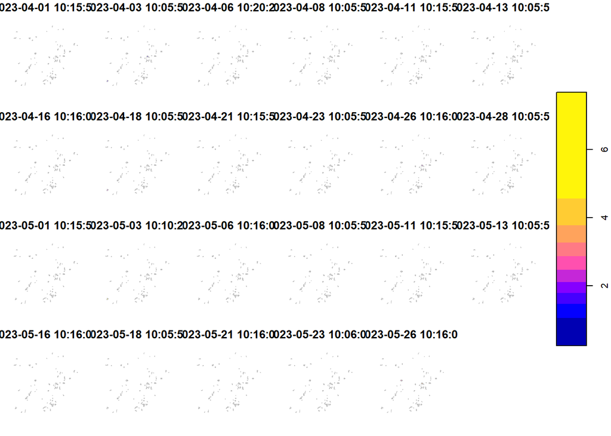

```r
aggrigated_lai_farms = aggregate(lai_stars, by = farms, FUN = mean)
plot(aggrigated_lai_farms, max.plot = 23, border = 'grey', lwd = .5)
```

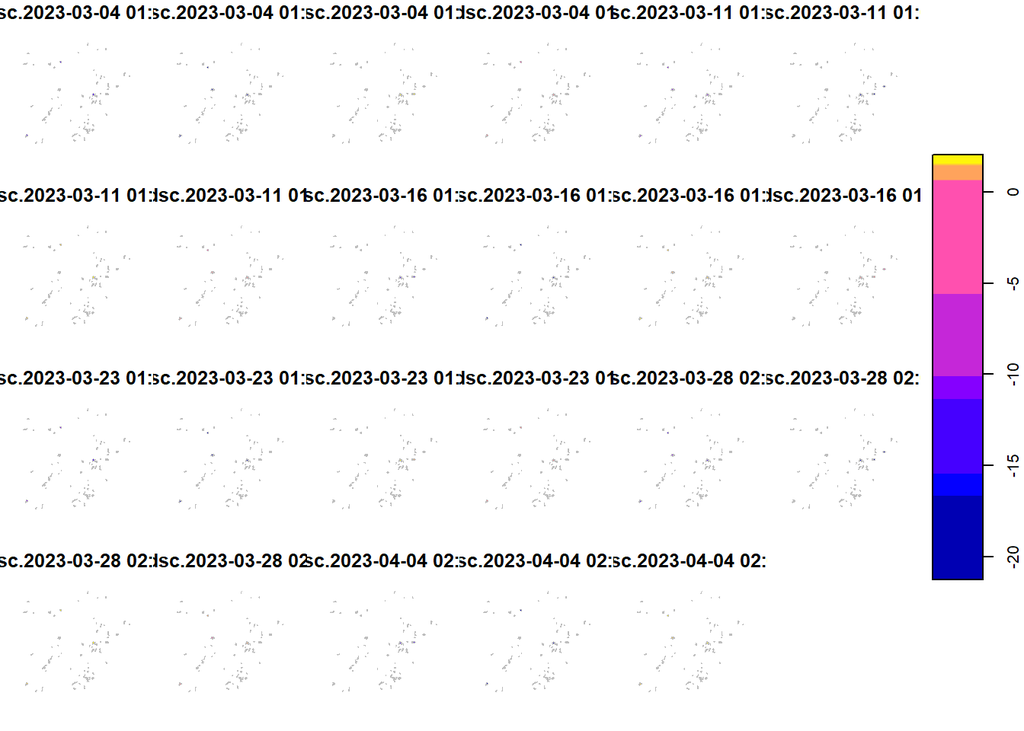

```r
aggregated_rtc_dsc_farms = aggregate(rtc_dsc_stars, by = farms, FUN = mean)
plot(aggregated_rtc_dsc_farms, max.plot = 23, border = 'grey', lwd = .5)
```

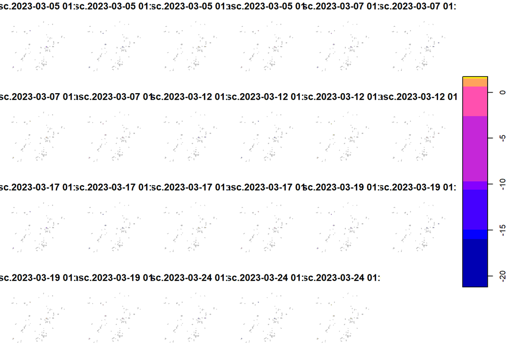

```r
aggregated_rtc_asc_farms = aggregate(rtc_asc_stars, by = farms, FUN = mean)
plot(aggregated_rtc_asc_farms, max.plot = 23, border = 'grey', lwd = .5)
```

**Python**

```python
## Create a map and check the location of each cluster
#center_lat, center_lon =  farms['Lat'].mean(), farms['Lon'].mean()

#map_farms = leafmap.Map(location=[center_lat, center_lon], zoom_start=13)
#map_farms.add_xyz_service("qms.EOX::Maps - Sentinel-2 cloudless")

#style_function = lambda x: {'fillColor': '#3366cc', 'color': '#3366cc'}

#folium.GeoJson(farms['geometry'], style_function=style_function).add_to(map_farms)
#map_farms

# Zonal statistcs
aggregated_lai_farms = lai_ds.xvec.zonal_stats(
    farms.geometry,
    x_coords="x",
    y_coords="y",
    stats="mean",
    name = "farm"
)
# Zonal statistcs
aggregated_rtc_dsc_farms = rtc_dsc.xvec.zonal_stats(
    farms.geometry,
    stats=["mean", "sum"],
    x_coords="x",
    y_coords="y",
    name = "farm"
)
# Zonal statistcs
aggregated_rtc_asc_farms = rtc_asc.xvec.zonal_stats(
    farms.geometry,
    stats=["mean", "sum"],
    x_coords="x",
    y_coords="y",
    name = "farm"
)
aggregated_rtc_asc_farms
```

```
<xarray.Dataset> Size: 138kB
Dimensions:           (zonal_statistics: 2, farm: 66, time: 65)
Coordinates:
    spatial_ref       int32 4B 0
  * time              (time) datetime64[ns] 520B 2023-03-05 ... 2023-11-26
  * zonal_statistics  (zonal_statistics) <U4 32B 'mean' 'sum'
  * farm              (farm) geometry 528B POLYGON ((699211.6412465982 518020...
Data variables:
    asc_vv            (farm, zonal_statistics, time) float32 34kB -9.565 ... ...
    asc_vh            (farm, zonal_statistics, time) float32 34kB -16.51 ... ...
    asc_rvi           (farm, zonal_statistics, time) float32 34kB 1.44 ... 13.99
    asc_vv/vh         (farm, zonal_statistics, time) float32 34kB 0.5719 ... ...
Indexes:
    farm     GeometryIndex (crs=EPSG:32632)
Attributes:
    STATISTICS_MAXIMUM:  11.263999938965
    STATISTICS_MEAN:     -9999
    STATISTICS_MINIMUM:  -19.91900062561
    STATISTICS_STDDEV:   -9999
    AREA_OR_POINT:       Area
    _FillValue:          nan
    scale_factor:        1.0
    add_offset:          0.0
    long_name:           ('RTC_VV', 'RTC_VH')
```

**Julia**

```julia
# lai
aggregated_lai_farms = zonal(mean, lai_ds, of=GeometryLookup(farms_subset_32632),
    threaded = true, skipmissing = true, spatialslices = true);
# all(isnan, aggregated_lai_farms), all(ismissing, aggregated_lai_farms)
# ascending
aggregated_rtc_asc_farms = zonal(mean, rtc_asc, of=GeometryLookup(farms_subset_32632),
    threaded = true, skipmissing = true, spatialslices = true)
```

```
┌ 65×4×66 Raster{Float32, 3} data ┐
├─────────────────────────────────┴────────────────────────────────────── dims ┐
  ↓ Ti Sampled{DateTime} [DateTime("2023-03-05T00:00:00"), …, DateTime("2023-11-26T00:00:00")] ForwardOrdered Irregular Points,
  → Band Categorical{String} ["asc_RTC_VV", …, "asc_RVI"] Unordered,
  ↗ Geometry GeometryLookup{GeoInterface.Wrappers.MultiPolygon{false, false, Vector{GeoInterface.Wrappers.Polygon{false, false, Vector{GeoInterface.Wrappers.LinearRing{false, false, Vector{Tuple{Float64, Float64}}, Nothing, EPSG{1}}}, Nothing, EPSG{1}}}, Nothing, EPSG{1}}} [GeoInterface.Wrappers.Mul…
├──────────────────────────────────────────────────────────────────── metadata ┤
  Metadata{Rasters.GDALsource} of Dict{String, Any} with 1 entry:
  "filepath" => "C:/Users/Yomna Eid/Documents/1b. PhD/DataCubes_Tutorial/rtc_as…
├────────────────────────────────────────────────────────────────────── raster ┤
  extent: Extent(Ti = (DateTime("2023-03-05T00:00:00"), DateTime("2023-11-26T00:00:00")), Band = (nothing, nothing), Geometry = ((698941.2695879079, 707740.7816466214), (5.172798306473953e6, 5.181102804580509e6)))
  crs: EPSG:32632
└──────────────────────────────────────────────────────────────────────────────┘
```

```julia
# descending
aggregated_rtc_dsc_farms = zonal(mean, rtc_dsc, of=GeometryLookup(farms_subset_32632),
    threaded = true, skipmissing = true, spatialslices = true);

aggregated_rtc_asc_farms[Ti=1]
```

```
┌ 4×66 Raster{Float32, 2} data ┐
├──────────────────────────────┴───────────────────────────────────────── dims ┐
  ↓ Band Categorical{String} ["asc_RTC_VV", …, "asc_RVI"] Unordered,
  → Geometry GeometryLookup{GeoInterface.Wrappers.MultiPolygon{false, false, Vector{GeoInterface.Wrappers.Polygon{false, false, Vector{GeoInterface.Wrappers.LinearRing{false, false, Vector{Tuple{Float64, Float64}}, Nothing, EPSG{1}}}, Nothing, EPSG{1}}}, Nothing, EPSG{1}}} [GeoInterface.Wrappers.Mul…
├──────────────────────────────────────────────────────────────────── metadata ┤
  Metadata{Rasters.GDALsource} of Dict{String, Any} with 1 entry:
  "filepath" => "C:/Users/Yomna Eid/Documents/1b. PhD/DataCubes_Tutorial/rtc_as…
├────────────────────────────────────────────────────────────────────── raster ┤
  extent: Extent(Band = (nothing, nothing), Geometry = ((698941.2695879079, 707740.7816466214), (5.172798306473953e6, 5.181102804580509e6)))
  crs: EPSG:32632
└──────────────────────────────────────────────────────────────────────────────┘
 ↓ →            …     GeoInterface.Wrappers.MultiPolygon([GeoInterface.Wrappers.Polygon([GeoInterface.Wrappers.LinearRing([(705279.5011261452,5.176938311637385e6),…(33)…,(705279.5011261452,5.176938311637385e6)])])])
  "asc_RTC_VV"     -10.2988
  "asc_RTC_VH"     -17.9139
  "asc_VV/VH"        0.573102
  "asc_RVI"          2.54335
```

```julia
aggregated_rtc_dsc_farms[Ti=1]
```

```
┌ 4×66 Raster{Float32, 2} data ┐
├──────────────────────────────┴───────────────────────────────────────── dims ┐
  ↓ Band Categorical{String} ["dsc_RTC_VV", …, "dsc_RVI"] Unordered,
  → Geometry GeometryLookup{GeoInterface.Wrappers.MultiPolygon{false, false, Vector{GeoInterface.Wrappers.Polygon{false, false, Vector{GeoInterface.Wrappers.LinearRing{false, false, Vector{Tuple{Float64, Float64}}, Nothing, EPSG{1}}}, Nothing, EPSG{1}}}, Nothing, EPSG{1}}} [GeoInterface.Wrappers.Mul…
├──────────────────────────────────────────────────────────────────── metadata ┤
  Metadata{Rasters.GDALsource} of Dict{String, Any} with 1 entry:
  "filepath" => "C:/Users/Yomna Eid/Documents/1b. PhD/DataCubes_Tutorial/rtc_ds…
├────────────────────────────────────────────────────────────────────── raster ┤
  extent: Extent(Band = (nothing, nothing), Geometry = ((698941.2695879079, 707740.7816466214), (5.172798306473953e6, 5.181102804580509e6)))
  crs: EPSG:32632
└──────────────────────────────────────────────────────────────────────────────┘
 ↓ →            …     GeoInterface.Wrappers.MultiPolygon([GeoInterface.Wrappers.Polygon([GeoInterface.Wrappers.LinearRing([(705279.5011261452,5.176938311637385e6),…(33)…,(705279.5011261452,5.176938311637385e6)])])])
  "dsc_RTC_VV"     -12.1251
  "dsc_RTC_VH"     -19.1942
  "dsc_VV/VH"        0.636073
  "dsc_RVI"          2.45025
```

**R**

Indexing and selecting data

Select specific farm

```r
farm_id <- 1782222
```

**Python**

```python
farms.head(3)
```

```
        ID CODE  ...              x             y
0  1782222  AP2  ...  699317.948254  5.180237e+06
1  2452708  AP2  ...  700491.273765  5.173058e+06
2  2753189  AP2  ...  703693.920050  5.175822e+06

[3 rows x 15 columns]
```

```python
# Select specific farm
farm_id = 1782222
```

**Julia**

```julia
# Select a specific farm
farm_id = 1782222
```

```
1782222
```

**R**

Select the specific farm by ID

```r
selected_farm <- farms[farms$ID == farm_id, ]
```

**Python**

```python
selected_farm = farms[farms["ID"] ==  farm_id]
```

**Julia**

```julia
selected_farm = filter(:ID => ==(farm_id), farms_subset_32632)
```

```
1×12 DataFrame
 Row │ geometry                           ID       CODE     DESCR_IT       DES ⋯
     │ MultiPol…                          Int64?   String?  String?        Str ⋯
─────┼──────────────────────────────────────────────────────────────────────────
   1 │ GeoInterface.Wrappers.MultiPolyg…  1782222  AP2      Prato stabile  Wie ⋯
                                                               8 columns omitted
```

**R**

Extract the geometry of the selected farm

```r
farm <- selected_farm$geometry[1]
#farm = farms$geometry[1]

aggrigated_lai_farms[st_as_sf(farm)]
```

```
stars object with 2 dimensions and 1 attribute
attribute(s):
          Min.  1st Qu.   Median     Mean  3rd Qu.     Max. NA's
lai  0.8699118 1.980636 2.687662 2.979478 4.338426 5.312676   49
dimension(s):
         from to                refsys point
geometry    1  1 WGS 84 / UTM zone 32N FALSE
time        1 77               POSIXct    NA
                                              values
geometry              MULTIPOLYGON (((699212 5180...
time     2023-04-01 10:15:59,...,2023-10-30 10:11:41
```

**Python**

```python
geom = selected_farm.geometry[0]
selected_farm
```

```
        ID CODE  ...              x             y
0  1782222  AP2  ...  699317.948254  5.180237e+06

[1 rows x 15 columns]
```

**Julia**

```julia
geom = only(selected_farm.geometry)
```

```
GeoInterface.Wrappers.MultiPolygon{false, false}([GeoInterface.Wrappers.Polygon([GeoInterface.Wrappers.LinearRing([(699211.6412465982, 5.180209025860044e6), … (86) … , (699211.6412465982, 5.180209025860044e6)], crs = "EPSG:32632")], crs = "EPSG:32632")], crs = "EPSG:32632")
```

```julia
# Select S1 ASC RTC data based on the geometry of the selected farm
selected_farm = aggregated_rtc_asc_farms[Geometry=At(geom)]
```

```
┌ 65×4 Raster{Float32, 2} data ┐
├──────────────────────────────┴───────────────────────────────────────── dims ┐
  ↓ Ti Sampled{DateTime} [DateTime("2023-03-05T00:00:00"), …, DateTime("2023-11-26T00:00:00")] ForwardOrdered Irregular Points,
  → Band Categorical{String} ["asc_RTC_VV", …, "asc_RVI"] Unordered
├──────────────────────────────────────────────────────────────────── metadata ┤
  Metadata{Rasters.GDALsource} of Dict{String, Any} with 1 entry:
  "filepath" => "C:/Users/Yomna Eid/Documents/1b. PhD/DataCubes_Tutorial/rtc_as…
├────────────────────────────────────────────────────────────────────── raster ┤
  extent: Extent(Ti = (DateTime("2023-03-05T00:00:00"), DateTime("2023-11-26T00:00:00")), Band = (nothing, nothing))
└──────────────────────────────────────────────────────────────────────────────┘
 ↓ →                      "asc_RTC_VV"  …   "asc_VV/VH"   "asc_RVI"
  2023-03-05T00:00:00   -9.56456           0.571877      2.56
  2023-03-07T00:00:00  -10.4428            0.609914      2.4925
 ⋮                                      ⋱
  2023-11-24T00:00:00   -9.46637           0.644701      2.43444
  2023-11-26T00:00:00  -10.8623         …  0.623446      2.47177
```

**R**

Add buffer around the farm

```r
buffered_farm <- st_buffer(farm, dist = 2500)  # distance is in meters
aggrigated_lai_farms[st_as_sf(buffered_farm)]
```

```
stars object with 2 dimensions and 1 attribute
attribute(s):
          Min.  1st Qu.   Median     Mean  3rd Qu.     Max. NA's
lai  0.5751458 1.757146 2.582779 2.747524 3.741868 6.530531  276
dimension(s):
         from to                refsys point
geometry    1  5 WGS 84 / UTM zone 32N FALSE
time        1 77               POSIXct    NA
                                                                values
geometry MULTIPOLYGON (((699211.6 ...,...,MULTIPOLYGON (((698941.3 ...
time                       2023-04-01 10:15:59,...,2023-10-30 10:11:41
```

**Python**

```python
# Select S1 ASC RTC data based on the geometry of the selected farm
selected_farm = aggregated_rtc_asc_farms.sel(farm=[geom])
# Select LAI data within 2.5 km around the geometry of the selected farm
selected_farms = aggregated_lai_farms.xvec.query("farm", [geom.buffer(2500)])
```

**Julia**

```julia
#Select LAI data within 2.5 km around the geometry of the selected farm

buffered_geom = GO.buffer(geom, 2500)
```

```
GeoInterface.Wrappers.Polygon{false, false}([GeoInterface.Wrappers.LinearRing([(696964.6258712846, 5.179124473906611e6), … (64) … , (696964.6258712846, 5.179124473906611e6)], crs = "EPSG:32632")], crs = "EPSG:32632")
```

```julia
datacube_lai_farms = aggregated_lai_farms[Geometry = Where(Base.Fix1(GO.intersects, buffered_geom))]
```

```
┌ 77×5 Raster{Float32, 2} data ┐
├──────────────────────────────┴───────────────────────────────────────── dims ┐
  ↓ Ti Sampled{DateTime} [DateTime("2023-04-01T10:15:59"), …, DateTime("2023-10-30T10:11:41")] ForwardOrdered Irregular Points,
  → Geometry GeometryLookup{GeoInterface.Wrappers.MultiPolygon{false, false, Vector{GeoInterface.Wrappers.Polygon{false, false, Vector{GeoInterface.Wrappers.LinearRing{false, false, Vector{Tuple{Float64, Float64}}, Nothing, EPSG{1}}}, Nothing, EPSG{1}}}, Nothing, EPSG{1}}} [GeoInterface.Wrappers.Mul…
├──────────────────────────────────────────────────────────────────── metadata ┤
  Metadata{Rasters.GDALsource} of Dict{String, Any} with 1 entry:
  "filepath" => "C:/Users/Yomna Eid/Documents/1b. PhD/DataCubes_Tutorial/lai_cr…
├────────────────────────────────────────────────────────────────────── raster ┤
  extent: Extent(Ti = (DateTime("2023-04-01T10:15:59"), DateTime("2023-10-30T10:11:41")), Geometry = ((698941.2695879079, 701549.6722082897), (5.179037090024233e6, 5.180292920543719e6)))
  crs: EPSG:32632
└──────────────────────────────────────────────────────────────────────────────┘
 ↓ →                   …     GeoInterface.Wrappers.MultiPolygon([GeoInterface.Wrappers.Polygon([GeoInterface.Wrappers.LinearRing([(698941.2695879079,5.179380930475065e6),…(168)…,(698941.2695879079,5.179380930475065e6)])])])
  2023-04-01T10:15:59     NaN
  2023-04-03T10:05:51       2.40429
 ⋮                     ⋱    ⋮
  2023-10-23T10:21:01       1.17262
  2023-10-30T10:11:41     NaN
```

**R**

Data Matching

Time values

```r
lai_times <- st_get_dimension_values(aggrigated_lai_farms, "time")
asc_times <- st_get_dimension_values(aggregated_rtc_asc_farms, "time")
dsc_times <- st_get_dimension_values(aggregated_rtc_dsc_farms, "time")
```

**Python**

```python
# Test 2
```

**Julia**

```julia
lai_timeaxis = dims(aggregated_lai_farms, Ti)
```

```
Ti Sampled{DateTime} ForwardOrdered Irregular DimensionalData.Dimensions.Lookups.Points
wrapping: 77-element view(::Vector{DateTime}, :) with eltype DateTime:
 2023-04-01T10:15:59
 2023-04-03T10:05:51
 2023-04-06T10:20:21
 2023-04-08T10:05:59
 2023-04-11T10:15:59
 2023-04-13T10:05:51
 2023-04-16T10:16:01
 2023-04-18T10:05:59
 2023-04-21T10:15:59
 2023-04-23T10:05:51
 ⋮
 2023-09-18T10:16:49
 2023-09-20T10:07:11
 2023-09-23T10:17:31
 2023-09-25T10:06:49
 2023-09-28T10:17:19
 2023-09-30T10:08:11
 2023-10-20T10:10:31
 2023-10-23T10:21:01
 2023-10-30T10:11:41
```

**R**

Initialize storage

```r
matched_lai <- list()
matched_asc <- list()
matched_dsc <- list()
matched_dsc_times <- c()
matched_asc_times <- c()
matched_times <- c()
```

**Python**

```python
# Initialize storage
matched_lai = []
matched_asc = []
matched_dsc = []
## to store the mathced times
matched_times_asc = []
matched_times_dsc = []
matched_times = []
```

**Julia**

**R**

Tolerance in days

```r
tolerance_days <- 3
```

**Python**

```python
# Tolerance in days
tolerance = 3
```

**Julia**

```julia
tolerance_interval = ClosedInterval.(lai_timeaxis .- Day(3), lai_timeaxis .+ Day(3))
```

```
┌ 77-element DimArray{ClosedInterval{DateTime}, 1} ┐
├──────────────────────────────────────────────────┴───────────────────── dims ┐
  ↓ Ti Sampled{DateTime} [DateTime("2023-04-01T10:15:59"), …, DateTime("2023-10-30T10:11:41")] ForwardOrdered Irregular Points
└──────────────────────────────────────────────────────────────────────────────┘
 2023-04-01T10:15:59  2023-03-29T10:15:59 .. 2023-04-04T10:15:59
 2023-04-03T10:05:51  2023-03-31T10:05:51 .. 2023-04-06T10:05:51
 2023-04-06T10:20:21  2023-04-03T10:20:21 .. 2023-04-09T10:20:21
 2023-04-08T10:05:59  2023-04-05T10:05:59 .. 2023-04-11T10:05:59
 2023-04-11T10:15:59  2023-04-08T10:15:59 .. 2023-04-14T10:15:59
 ⋮
 2023-09-28T10:17:19  2023-09-25T10:17:19 .. 2023-10-01T10:17:19
 2023-09-30T10:08:11  2023-09-27T10:08:11 .. 2023-10-03T10:08:11
 2023-10-20T10:10:31  2023-10-17T10:10:31 .. 2023-10-23T10:10:31
 2023-10-23T10:21:01  2023-10-20T10:21:01 .. 2023-10-26T10:21:01
 2023-10-30T10:11:41  2023-10-27T10:11:41 .. 2023-11-02T10:11:41
```

```julia
first(tolerance_interval, 3)
```

```
┌ 3-element DimArray{ClosedInterval{DateTime}, 1} ┐
├─────────────────────────────────────────────────┴────────────────────── dims ┐
  ↓ Ti Sampled{DateTime} [DateTime("2023-04-01T10:15:59"), …, DateTime("2023-04-06T10:20:21")] ForwardOrdered Irregular Points
└──────────────────────────────────────────────────────────────────────────────┘
 2023-04-01T10:15:59  2023-03-29T10:15:59 .. 2023-04-04T10:15:59
 2023-04-03T10:05:51  2023-03-31T10:05:51 .. 2023-04-06T10:05:51
 2023-04-06T10:20:21  2023-04-03T10:20:21 .. 2023-04-09T10:20:21
```

**R**

```r
for (i in seq_along(lai_times)) {
  t1 <- lai_times[i]
  # Find matches in asc and dsc
  asc_diff <- abs(difftime(asc_times, t1, units = "days"))
  dsc_diff <- abs(difftime(dsc_times, t1, units = "days"))

  asc_match_idx <- which(asc_diff <= tolerance_days)
  dsc_match_idx <- which(dsc_diff <= tolerance_days)

  if (length(asc_match_idx) > 0 && length(dsc_match_idx) > 0) {
    # Choose latest match in each
    asc_time <- asc_times[asc_match_idx[length(asc_match_idx)]]
    dsc_time <- dsc_times[dsc_match_idx[length(dsc_match_idx)]]

    # Only keep unique time match sets
    if ((!(asc_time %in% matched_asc_times)) && (!(dsc_time %in% matched_dsc_times))) {
      matched_lai[[length(matched_lai) + 1]] <- aggrigated_lai_farms[,,i, drop = FALSE]
      matched_asc[[length(matched_asc) + 1]] <- aggregated_rtc_asc_farms[,,,asc_match_idx[length(asc_match_idx)], drop = FALSE]
      matched_dsc[[length(matched_dsc) + 1]] <- aggregated_rtc_dsc_farms[,,,dsc_match_idx[length(dsc_match_idx)], drop = FALSE]
      matched_dsc_times <- c(matched_dsc_times, dsc_time)
      matched_asc_times <- c(matched_asc_times, asc_time)
      matched_times <- c(matched_times, t1)
    }
  }
}
```

**Python**

```python
# iterate over the time coordinates of LAI dataset
for idx, t1 in enumerate(aggregated_lai_farms.time.values):
    # find the corresponding time coordinates in S1 RTC dataset within the tolerance

    # Match with S1 asc
    asc_time_diff = np.abs((aggregated_rtc_asc_farms.time.values - t1)) / np.timedelta64(1, 'D')
    dsc_time_diff = np.abs((aggregated_rtc_dsc_farms.time.values - t1)) / np.timedelta64(1, 'D')

    asc_mask = asc_time_diff <= tolerance
    dsc_mask = dsc_time_diff <= tolerance


    if np.any(asc_mask) and np.any(dsc_mask):
        asc_time = aggregated_rtc_asc_farms.time.values[asc_mask][-1]
        dsc_time = aggregated_rtc_dsc_farms.time.values[dsc_mask][-1]

        if (asc_time not in matched_times_asc) and (dsc_time not in matched_times_dsc):  #(not np.isin(asc_time[-1], matched_times_asc)) and (not np.isin(dsc_time[-1], matched_times_dsc)):
            #print(t1)
            matched_lai.append(aggregated_lai_farms.sel(time=t1))
            matched_asc.append(aggregated_rtc_asc_farms.sel(time=asc_time))
            matched_dsc.append(aggregated_rtc_dsc_farms.sel(time=dsc_time))

            matched_times_asc.append(asc_time)
            matched_times_dsc.append(dsc_time)
            matched_times.append(t1)
```

**Julia**

```julia
filter_asc =  filter(x-> !iszero(size(x, Ti)),
    getindex.((aggregated_rtc_asc_farms,), Ti.(tolerance_interval)))
```

```
┌ 76-element DimArray{Raster{Float32, 3, Tuple{Ti{DimensionalData.Dimensions.Lookups.Sampled{DateTime, Vector{DateTime}, DimensionalData.Dimensions.Lookups.ForwardOrdered, DimensionalData.Dimensions.Lookups.Irregular{Tuple{Nothing, Nothing}}, DimensionalData.Dimensions.Lookups.Points, DimensionalDat…
├──────────────────────────────────────────────────────────────────────── dims ┤
  ↓ Ti Sampled{DateTime} [DateTime("2023-04-03T10:05:51"), …, DateTime("2023-10-30T10:11:41")] ForwardOrdered Irregular Points
└──────────────────────────────────────────────────────────────────────────────┘
 2023-04-03T10:05:51  …  Float32[-10.7468 -16.5398 0.648238 2.43153;;; -12.1106 -17.9316 0.676187 2.39016;;; -10.9837 -17.9074 0.610163 2.48906;;; … ;;; -11.2611 -17.1468 0.655886 2.41903;;; -10.4555 -15.881 0.657178 2.4174;;; -10.9291 -17.7456 0.622062 2.4719]
 2023-04-06T10:20:21     Float32[-10.7468 -16.5398 0.648238 2.43153;;; -12.1106 -17.9316 0.676187 2.39016;;; -10.9837 -17.9074 0.610163 2.48906;;; … ;;; -11.2611 -17.1468 0.655886 2.41903;;; -10.4555 -15.881 0.657178 2.4174;;; -10.9291 -17.7456 0.622062 2.4719]
 2023-04-08T10:05:59     Float32[-11.9628 -16.6425 0.717562 2.33055;;; -10.3184 -16.2004 0.635443 2.45992;;; -10.028 -14.8571 0.670206 2.4013;;; … ;;; -10.0173 -15.4351 0.642192 2.44434;;; -11.3102 -17.7258 0.629191 2.45972;;; -12.9146 -17.18 0.751332 2.28439]
 2023-04-11T10:15:59     Float32[-11.9628 -16.6425 0.717562 2.33055; -11.2325 -17.7288 0.633506 2.45522;;; -10.3184 -16.2004 0.635443 2.45992; -11.8429 -17.9529 0.661136 2.41231;;; -10.028 -14.8571 0.670206 2.4013; -11.2686 -17.2435 0.652499 2.42881;;; … ;;; -10.0173 -15.4351 0.642192 2.44434; -10.2…
 2023-04-13T10:05:51     Float32[-11.2325 -17.7288 0.633506 2.45522;;; -11.8429 -17.9529 0.661136 2.41231;;; -11.2686 -17.2435 0.652499 2.42881;;; … ;;; -10.2445 -16.795 0.610969 2.48972;;; -11.3695 -18.1402 0.630392 2.45949;;; -12.4019 -17.4252 0.711203 2.33797]
 ⋮                    ⋱
 2023-09-28T10:17:19     Float32[-10.0306 -16.9124 0.59229 2.51693;;; -9.87405 -16.0307 0.618504 2.47685;;; -10.0756 -16.2533 0.618992 2.47333;;; … ;;; -10.065 -15.5775 0.645361 2.43602;;; -9.1015 -15.9217 0.570725 2.59575;;; -10.1962 -17.6026 0.583681 2.5316]
 2023-09-30T10:08:11     Float32[-10.1306 -15.6476 0.648959 2.43034;;; -10.9511 -16.7036 0.655407 2.41856;;; -9.9879 -16.5332 0.598881 2.51149;;; … ;;; -10.3983 -16.2097 0.639479 2.44328;;; -8.98153 -15.4387 0.577949 2.54285;;; -9.84522 -16.4018 0.587623 2.52431]
 2023-10-20T10:10:31     Float32[-9.69537 -16.0964 0.60218 2.49855; -8.88236 -14.7353 0.603113 2.49959;;; -10.0694 -16.0889 0.622721 2.46735; -8.43789 -14.8233 0.565886 2.56019;;; -9.43097 -15.6397 0.6026 2.50578; -7.67051 -14.1428 0.546277 2.59337;;; … ;;; -10.1795 -15.9721 0.634631 2.45353; -8.631…
 2023-10-23T10:21:01     Float32[-8.88236 -14.7353 0.603113 2.49959;;; -8.43789 -14.8233 0.565886 2.56019;;; -7.67051 -14.1428 0.546277 2.59337;;; … ;;; -8.63156 -14.769 0.585246 2.52936;;; -7.32164 -14.2309 0.508538 2.66436;;; -9.187 -14.7447 0.62034 2.46983]
 2023-10-30T10:11:41  …  Float32[-8.58287 -14.2543 0.600777 2.50306;;; -8.75037 -14.8998 0.583617 2.53042;;; -7.77214 -14.1906 0.548237 2.59167;;; … ;;; -8.43374 -14.4474 0.583509 2.53103;;; -8.58325 -14.4177 0.595642 2.51251;;; -9.07456 -14.4319 0.628983 2.45613]
```

```julia
# get dates
asc_dates = lookup(filter_asc, Ti);

filter_dsc =  filter(x-> !iszero(size(x, Ti)),
    getindex.((aggregated_rtc_dsc_farms,), Ti.(tolerance_interval)))
```

```
┌ 70-element DimArray{Raster{Float32, 3, Tuple{Ti{DimensionalData.Dimensions.Lookups.Sampled{DateTime, Vector{DateTime}, DimensionalData.Dimensions.Lookups.ForwardOrdered, DimensionalData.Dimensions.Lookups.Irregular{Tuple{Nothing, Nothing}}, DimensionalData.Dimensions.Lookups.Points, DimensionalDat…
├──────────────────────────────────────────────────────────────────────── dims ┤
  ↓ Ti Sampled{DateTime} [DateTime("2023-04-01T10:15:59"), …, DateTime("2023-10-30T10:11:41")] ForwardOrdered Irregular Points
└──────────────────────────────────────────────────────────────────────────────┘
 2023-04-01T10:15:59  …  Float32[-12.5933 -18.1875 0.693704 2.36533;;; -12.6822 -18.7936 0.673168 2.39524;;; -12.2754 -18.3981 0.664872 2.40861;;; … ;;; -12.0957 -18.4298 0.640329 2.25361;;; -12.1018 -18.79 0.6377 2.45016;;; -9.40556 -17.3463 0.540061 2.60106]
 2023-04-03T10:05:51     Float32[-12.5933 -18.1875 0.693704 2.36533;;; -12.6822 -18.7936 0.673168 2.39524;;; -12.2754 -18.3981 0.664872 2.40861;;; … ;;; -12.0957 -18.4298 0.640329 2.25361;;; -12.1018 -18.79 0.6377 2.45016;;; -9.40556 -17.3463 0.540061 2.60106]
 2023-04-06T10:20:21     Float32[-12.5933 -18.1875 0.693704 2.36533; -12.1766 -18.4144 0.644167 2.47006;;; -12.6822 -18.7936 0.673168 2.39524; -10.8714 -17.7631 0.60864 2.49853;;; -12.2754 -18.3981 0.664872 2.40861; -12.538 -18.6928 0.671829 2.39533;;; … ;;; -12.0957 -18.4298 0.640329 2.25361; -12.0…
 2023-04-08T10:05:59     Float32[-12.1766 -18.4144 0.644167 2.47006;;; -10.8714 -17.7631 0.60864 2.49853;;; -12.538 -18.6928 0.671829 2.39533;;; … ;;; -12.0477 -19.5732 0.61341 2.49448;;; -11.4078 -17.4228 0.658679 2.41879;;; -12.6084 -18.6537 0.677309 2.38504]
 2023-04-11T10:15:59     Float32[-12.1766 -18.4144 0.644167 2.47006;;; -10.8714 -17.7631 0.60864 2.49853;;; -12.538 -18.6928 0.671829 2.39533;;; … ;;; -12.0477 -19.5732 0.61341 2.49448;;; -11.4078 -17.4228 0.658679 2.41879;;; -12.6084 -18.6537 0.677309 2.38504]
 ⋮                    ⋱
 2023-09-25T10:06:49  …  Float32[-10.4772 -15.6873 0.66686 2.40266;;; -10.5852 -16.6912 0.631159 2.45485;;; -9.23295 -15.7203 0.582734 2.5307;;; … ;;; -9.74277 -16.5591 0.584058 2.54423;;; -10.5709 -16.5673 0.626169 2.48183;;; -11.2481 -17.8203 0.631326 2.45299]
 2023-09-28T10:17:19     Float32[-11.6376 -17.9907 0.647967 2.42802;;; -10.1586 -16.2223 0.621822 2.4709;;; -9.84881 -16.2649 0.603296 2.50207;;; … ;;; -10.7127 -17.4182 0.615874 2.4786;;; -11.7601 -17.821 0.657965 2.41471;;; -10.666 -15.6183 0.681303 2.37976]
 2023-09-30T10:08:11     Float32[-11.6376 -17.9907 0.647967 2.42802;;; -10.1586 -16.2223 0.621822 2.4709;;; -9.84881 -16.2649 0.603296 2.50207;;; … ;;; -10.7127 -17.4182 0.615874 2.4786;;; -11.7601 -17.821 0.657965 2.41471;;; -10.666 -15.6183 0.681303 2.37976]
 2023-10-23T10:21:01     Float32[-9.46139 -15.5444 0.60786 2.49202;;; -9.13347 -15.4083 0.590868 2.5187;;; -8.36786 -14.4669 0.576905 2.54284;;; … ;;; -9.71469 -15.2517 0.634759 2.44959;;; -8.41092 -15.4272 0.544741 2.59654;;; -9.99711 -16.1556 0.618604 2.47158]
 2023-10-30T10:11:41     Float32[-10.0936 -16.1166 0.624799 2.46671;;; -9.78489 -15.5211 0.627436 2.46438;;; -9.60715 -16.1902 0.577235 2.56118;;; … ;;; -9.78078 -15.9303 0.607154 2.49544;;; -10.0158 -16.1943 0.617712 2.47424;;; -8.33989 -14.0619 0.591072 2.52004]
```

```julia
dsc_dates = lookup(filter_dsc, Ti);

lai_dates = lookup(lai_ds, Ti)
```

```
Sampled{DateTime} ForwardOrdered Irregular DimensionalData.Dimensions.Lookups.Points
wrapping: 77-element Vector{DateTime}:
 2023-04-01T10:15:59
 2023-04-03T10:05:51
 2023-04-06T10:20:21
 2023-04-08T10:05:59
 2023-04-11T10:15:59
 2023-04-13T10:05:51
 2023-04-16T10:16:01
 2023-04-18T10:05:59
 2023-04-21T10:15:59
 2023-04-23T10:05:51
 ⋮
 2023-09-18T10:16:49
 2023-09-20T10:07:11
 2023-09-23T10:17:31
 2023-09-25T10:06:49
 2023-09-28T10:17:19
 2023-09-30T10:08:11
 2023-10-20T10:10:31
 2023-10-23T10:21:01
 2023-10-30T10:11:41
```

```julia
# Get the dates of the LAI data that match the dates of the RTC data
filter_dates = filter(x -> x in asc_dates && x in dsc_dates, lai_dates);

asc_interval = filter_asc[Ti = At(filter_dates)];
dsc_interval = filter_dsc[Ti = At(filter_dates)];
lai_interval = permutedims(aggregated_lai_farms[Ti = At(filter_dates)], (2,1));

asc_1 = [asc_interval[k][Ti=1] for k in eachindex(asc_interval)]; # ? really, like this?
```

```
┌ 69-element DimArray{Raster{Float32, 2, Tuple{Rasters.Band{DimensionalData.Dimensions.Lookups.Categorical{String, Vector{String}, DimensionalData.Dimensions.Lookups.Unordered, DimensionalData.Dimensions.Lookups.NoMetadata}}, Geometry{GeometryLookup{GeoInterface.Wrappers.MultiPolygon{false, false, V…
├──────────────────────────────────────────────────────────────────────── dims ┤
  ↓ Ti Sampled{DateTime} [DateTime("2023-04-03T10:05:51"), …, DateTime("2023-10-30T10:11:41")] ForwardOrdered Irregular Points
└──────────────────────────────────────────────────────────────────────────────┘
 2023-04-03T10:05:51  …  Float32[-10.7468 -12.1106 … -10.4555 -10.9291; -16.5398 -17.9316 … -15.881 -17.7456; 0.648238 0.676187 … 0.657178 0.622062; 2.43153 2.39016 … 2.4174 2.4719]
 2023-04-06T10:20:21     Float32[-10.7468 -12.1106 … -10.4555 -10.9291; -16.5398 -17.9316 … -15.881 -17.7456; 0.648238 0.676187 … 0.657178 0.622062; 2.43153 2.39016 … 2.4174 2.4719]
 2023-04-08T10:05:59     Float32[-11.9628 -10.3184 … -11.3102 -12.9146; -16.6425 -16.2004 … -17.7258 -17.18; 0.717562 0.635443 … 0.629191 0.751332; 2.33055 2.45992 … 2.45972 2.28439]
 2023-04-11T10:15:59     Float32[-11.9628 -10.3184 … -11.3102 -12.9146; -16.6425 -16.2004 … -17.7258 -17.18; 0.717562 0.635443 … 0.629191 0.751332; 2.33055 2.45992 … 2.45972 2.28439]
 2023-04-13T10:05:51     Float32[-11.2325 -11.8429 … -11.3695 -12.4019; -17.7288 -17.9529 … -18.1402 -17.4252; 0.633506 0.661136 … 0.630392 0.711203; 2.45522 2.41231 … 2.45949 2.33797]
 ⋮                    ⋱
 2023-09-25T10:06:49     Float32[-9.79543 -10.3006 … -9.61264 -8.75844; -15.996 -16.5446 … -15.4581 -14.4183; 0.617212 0.626831 … 0.616206 0.594384; 2.47886 2.46155 … 2.48482 2.5149]
 2023-09-28T10:17:19  …  Float32[-10.0306 -9.87405 … -9.1015 -10.1962; -16.9124 -16.0307 … -15.9217 -17.6026; 0.59229 0.618504 … 0.570725 0.583681; 2.51693 2.47685 … 2.59575 2.5316]
 2023-09-30T10:08:11     Float32[-10.1306 -10.9511 … -8.98153 -9.84522; -15.6476 -16.7036 … -15.4387 -16.4018; 0.648959 0.655407 … 0.577949 0.587623; 2.43034 2.41856 … 2.54285 2.52431]
 2023-10-23T10:21:01     Float32[-8.88236 -8.43789 … -7.32164 -9.187; -14.7353 -14.8233 … -14.2309 -14.7447; 0.603113 0.565886 … 0.508538 0.62034; 2.49959 2.56019 … 2.66436 2.46983]
 2023-10-30T10:11:41     Float32[-8.58287 -8.75037 … -8.58325 -9.07456; -14.2543 -14.8998 … -14.4177 -14.4319; 0.600777 0.583617 … 0.595642 0.628983; 2.50306 2.53042 … 2.51251 2.45613]
```

```julia
dsc_1 = [dsc_interval[k][Ti=1] for k in eachindex(dsc_interval)];
```

**R**

Combine each set and assign matched times

```r
combine_stars_with_time <- function(obj_list, times) {
  if (length(obj_list) > 0) {
    merged <- do.call(c, c(obj_list, along = "time"))
    #st_dimensions(merged)$time <- times
    merged <- st_set_dimensions(merged, "time", values = times, names = "time")
    return(merged)
  } else {
    return(NULL)
  }
}
matched_times <- as.POSIXct(matched_times, origin = "1970-01-01", tz = "UTC")

lai_merged <- combine_stars_with_time(matched_lai, matched_times)
asc_merged <- combine_stars_with_time(matched_asc, matched_times)
dsc_merged <- combine_stars_with_time(matched_dsc, matched_times)


if (!is.null(lai_merged) && !is.null(asc_merged) && !is.null(dsc_merged)) {
  merged_all_rtc <- c(asc_merged, dsc_merged, along="band")
} else {
  merged_all_rtc <- NULL
}
```

**Python**

```python
# concatenate the matched data
if matched_lai:
    merged_lai = xr.concat(matched_lai, dim='concat_dim')
else:
    merged_lai = xr.Dataset()

if matched_asc:
    merged_asc = xr.concat(matched_asc, dim='concat_dim')
else:
    merged_asc = xr.Dataset()

if matched_dsc:
    merged_dsc = xr.concat(matched_dsc, dim='concat_dim')
else:
    merged_dsc = xr.Dataset()

# merge the concatenated data
if not merged_lai.equals(xr.Dataset()) and not merged_asc.equals(xr.Dataset()) and not merged_dsc.equals(xr.Dataset()):
    merged_ds = xr.merge([merged_lai, merged_asc, merged_dsc], compat='override')
else:
    merged_ds = xr.Dataset()
merged_ds = merged_ds.assign_coords(concat_dim=merged_ds.time.values)
merged_ds = merged_ds.drop_vars('time')
merged_ds = merged_ds.rename_dims({'concat_dim': 'time'})
merged_ds = merged_ds.rename_vars({'concat_dim': 'time'})
```

**Julia**

```julia
asc_1cat = cat(asc_1..., dims=Ti(filter_dates));

dsc_1cat = cat(dsc_1..., dims=Ti(filter_dates));

all_cat = cat(asc_1cat, dsc_1cat; dims=Rasters.Band);

new_bands = Rasters.Band([dims(all_cat, Rasters.Band)..., "lai"])
```

```
Band ["asc_RTC_VV", …, "lai"]
```

```julia
lai_catt = cat([all_cat[Band=i] for i in 1:8]..., lai_interval; dims=new_bands);
```

**R**

Reshape the data to be in 2D format

Convert to data frames & target to long format

```r
predictors_df <- as.data.frame(merged_all_rtc) #, long = TRUE
target_df <- as.data.frame(lai_merged)
```

**Python**

```python
variable_names = list(merged_ds.data_vars.keys())
df = merged_ds.xvec.to_geodataframe()
```

**Julia**

```julia
df_bands = DataFrame(DimTable(lai_catt; layersfrom=:Band))
```

```
4554×11 DataFrame
  Row │ Geometry                           Ti                   Band_asc_RTC_V ⋯
      │ MultiPol…                          DateTime             Float32        ⋯
──────┼─────────────────────────────────────────────────────────────────────────
    1 │ GeoInterface.Wrappers.MultiPolyg…  2023-04-03T10:05:51        -10.7468 ⋯
    2 │ GeoInterface.Wrappers.MultiPolyg…  2023-04-03T10:05:51        -12.1106
    3 │ GeoInterface.Wrappers.MultiPolyg…  2023-04-03T10:05:51        -10.9837
    4 │ GeoInterface.Wrappers.MultiPolyg…  2023-04-03T10:05:51        -11.1868
    5 │ GeoInterface.Wrappers.MultiPolyg…  2023-04-03T10:05:51        -11.1082 ⋯
    6 │ GeoInterface.Wrappers.MultiPolyg…  2023-04-03T10:05:51         -9.8711
    7 │ GeoInterface.Wrappers.MultiPolyg…  2023-04-03T10:05:51        -11.2604
    8 │ GeoInterface.Wrappers.MultiPolyg…  2023-04-03T10:05:51        -11.7162
  ⋮   │                 ⋮                           ⋮                  ⋮       ⋱
 4548 │ GeoInterface.Wrappers.MultiPolyg…  2023-10-30T10:11:41         -8.8098 ⋯
 4549 │ GeoInterface.Wrappers.MultiPolyg…  2023-10-30T10:11:41         -8.2791
 4550 │ GeoInterface.Wrappers.MultiPolyg…  2023-10-30T10:11:41         -8.3464
 4551 │ GeoInterface.Wrappers.MultiPolyg…  2023-10-30T10:11:41         -8.7290
 4552 │ GeoInterface.Wrappers.MultiPolyg…  2023-10-30T10:11:41         -8.4337 ⋯
 4553 │ GeoInterface.Wrappers.MultiPolyg…  2023-10-30T10:11:41         -8.5832
 4554 │ GeoInterface.Wrappers.MultiPolyg…  2023-10-30T10:11:41         -9.0745
                                                 9 columns and 4539 rows omitted
```

```julia
size(df_bands)
```

```
(4554, 11)
```

```julia
# filter out rows with NaN values
df_clean = filter(row -> all(x -> !(x isa Number && isnan(x)), row), df_bands)
```

```
1273×11 DataFrame
  Row │ Geometry                           Ti                   Band_asc_RTC_V ⋯
      │ MultiPol…                          DateTime             Float32        ⋯
──────┼─────────────────────────────────────────────────────────────────────────
    1 │ GeoInterface.Wrappers.MultiPolyg…  2023-04-03T10:05:51        -10.7468 ⋯
    2 │ GeoInterface.Wrappers.MultiPolyg…  2023-04-03T10:05:51        -10.9837
    3 │ GeoInterface.Wrappers.MultiPolyg…  2023-04-03T10:05:51        -11.1868
    4 │ GeoInterface.Wrappers.MultiPolyg…  2023-04-03T10:05:51        -11.1082
    5 │ GeoInterface.Wrappers.MultiPolyg…  2023-04-03T10:05:51        -11.2604 ⋯
    6 │ GeoInterface.Wrappers.MultiPolyg…  2023-04-03T10:05:51        -11.7162
    7 │ GeoInterface.Wrappers.MultiPolyg…  2023-04-03T10:05:51        -10.0387
    8 │ GeoInterface.Wrappers.MultiPolyg…  2023-04-03T10:05:51         -9.8646
  ⋮   │                 ⋮                           ⋮                  ⋮       ⋱
 1267 │ GeoInterface.Wrappers.MultiPolyg…  2023-10-23T10:21:01         -8.4740 ⋯
 1268 │ GeoInterface.Wrappers.MultiPolyg…  2023-10-23T10:21:01         -8.2571
 1269 │ GeoInterface.Wrappers.MultiPolyg…  2023-10-23T10:21:01         -8.3574
 1270 │ GeoInterface.Wrappers.MultiPolyg…  2023-10-23T10:21:01         -8.9389
 1271 │ GeoInterface.Wrappers.MultiPolyg…  2023-10-23T10:21:01         -8.3676 ⋯
 1272 │ GeoInterface.Wrappers.MultiPolyg…  2023-10-23T10:21:01         -8.6315
 1273 │ GeoInterface.Wrappers.MultiPolyg…  2023-10-23T10:21:01         -7.3216
                                                 9 columns and 1258 rows omitted
```

```julia
size(df_clean)
```

```
(1273, 11)
```

```julia
first(df_clean,5)
```

```
5×11 DataFrame
 Row │ Geometry                           Ti                   Band_asc_RTC_VV ⋯
     │ MultiPol…                          DateTime             Float32         ⋯
─────┼──────────────────────────────────────────────────────────────────────────
   1 │ GeoInterface.Wrappers.MultiPolyg…  2023-04-03T10:05:51         -10.7468 ⋯
   2 │ GeoInterface.Wrappers.MultiPolyg…  2023-04-03T10:05:51         -10.9837
   3 │ GeoInterface.Wrappers.MultiPolyg…  2023-04-03T10:05:51         -11.1868
   4 │ GeoInterface.Wrappers.MultiPolyg…  2023-04-03T10:05:51         -11.1082
   5 │ GeoInterface.Wrappers.MultiPolyg…  2023-04-03T10:05:51         -11.2604 ⋯
                                                               8 columns omitted
```

**R**

Add day_of_year

```r
predictors_df$day_of_year <- yday(predictors_df$time)
target_df$day_of_year <- yday(target_df$time)
```

**Python**

```python
df = df.reset_index()
df['Day_of_Year'] = df['time'].dt.dayofyear
df_output = df
df_output.head(3)
```

```
                 time zonal_statistics  ...  dsc_vv/vh  Day_of_Year
0 2023-04-03 10:05:51             mean  ...   0.693704           93
1 2023-04-03 10:05:51              sum  ...  48.559299           93
2 2023-04-03 10:05:51             mean  ...   0.673168           93

[3 rows x 14 columns]
```

**Julia**

**R**

Pivot to wide so each variable is a column

```r
predictors_wide <- predictors_df %>%
  pivot_wider(
    id_cols = c(geometry, day_of_year),   #  explicitly keep these
    names_from = band,
    values_from = backscatter
  )

#Join predictors and target
final_df <- left_join(predictors_wide, target_df, by = c("geometry", "day_of_year"))
final_df_clean <- final_df %>% drop_na()
```

**Python**

```python
df_farms = df_output.groupby(["farm","Day_of_Year"])
lai_df = df_output.dropna().reset_index(drop=True)
lai_df.head(3)
```

```
                 time zonal_statistics  ...  dsc_vv/vh  Day_of_Year
0 2023-04-03 10:05:51             mean  ...   0.693704           93
1 2023-04-03 10:05:51              sum  ...  48.559299           93
2 2023-04-03 10:05:51             mean  ...   0.673168           93

[3 rows x 14 columns]
```

**Julia**

Modeling

**R**

Get centroid coordinates, then extract x and y in meters (works if CRS is projected)

```r
final_df_clean <- st_as_sf(final_df_clean, crs = st_crs(lai_merged))
centroids <- st_centroid(final_df_clean)
coords <- st_coordinates(centroids)
# Now, add the extracted x and y to your data
final_df_clean$x <- coords[,1]
final_df_clean$y <- coords[,2]
```

**Python**

```python
# Spatial cross validation with RMSE & MAE metrics
from sklearn.ensemble import RandomForestRegressor
from sklearn.model_selection import train_test_split, GroupKFold, cross_val_score
from sklearn.metrics import mean_squared_error, root_mean_squared_error, r2_score

lai_df = gpd.GeoDataFrame(lai_df, geometry='farm')
lai_df["x"] = lai_df.farm.centroid.x
lai_df["y"] = lai_df.farm.centroid.y
```

**Julia**

**R**

Create 5km spatial blocks

```r
block_size <- 5000  # 5 km
final_df_clean$block <- paste0(
  floor(final_df_clean$x / block_size), "_",
  floor(final_df_clean$y / block_size)
)
```

**Python**

```python
# Define block size in meters (5km blocks)
block_size = 5000
lai_df["block"] = (
    (lai_df["x"] // block_size).astype(str) + "_" +
    (lai_df["y"] // block_size).astype(str)
)
```

**Julia**

**R**

Get unique block IDs and assign letters

```r
unique_blocks <- unique(final_df_clean$block)
sorted_blocks <- sort(unique_blocks)
```

**Python**

```python
# Sample: lai_df["block"] contains strings like "123_456"
blocks = lai_df["block"].unique()
blocks.sort()  # optional: sort blocks consistently
```

**Julia**

**R**

Create a named vector of new labels

```r
new_labels <- LETTERS[1:length(sorted_blocks)]  # A, B, C, ...
names(new_labels) <- sorted_blocks
```

**Python**

```python
# Generate letter labels: A, B, ..., Z, AA, AB, ...
def generate_labels(n):
    alphabet = list(string.ascii_uppercase)
    labels = []
    while len(labels) < n:
        for first in [""] + alphabet:
            for second in alphabet:
                labels.append(first + second)
                if len(labels) == n:
                    return labels
labels = generate_labels(len(blocks))
```

**Julia**

**R**

Apply the new labels

```r
final_df_clean$block <- new_labels[final_df_clean$block]
```

**Python**

```python
# Create mapping from old to new
block_map = dict(zip(blocks, labels))

# Apply it
lai_df["block"] = lai_df["block"].map(block_map)
```

**Julia**

**R**

Visualize blocks

```r
table(final_df_clean$block)
```

```
  A   B   C   D   E   F   G   H
 14  41  14 233 188  27 117  27
```

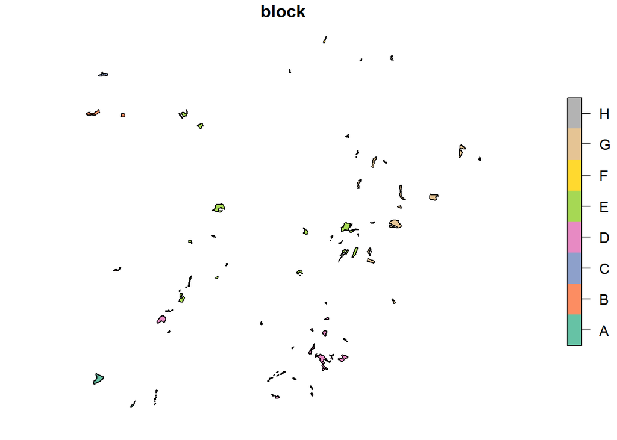

```r
plot(final_df_clean["block"])
```

**Python**

```python
print(lai_df["block"].unique())
```

```
['C' 'D' 'E' 'G' 'A' 'B' 'F' 'H']
```

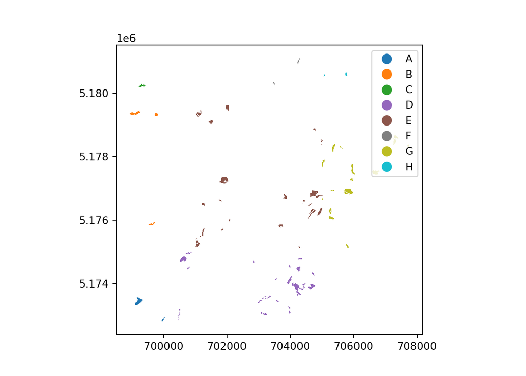

```python
lai_df.plot(column="block", legend=True)
```

**Julia**

**R**

Prepare data for modeling

```r
#Define response and predictors
target_var <- "lai"
predictors <- setdiff(names(final_df_clean), c("geometry", "block", "x", "y", "time","day_of_year", target_var))

model_data <- final_df_clean %>%
  dplyr::select(all_of(c(target_var, predictors, "block"))) %>%
  st_drop_geometry() %>%
  na.omit()
```

**Python**

```python
# Clean data
groups = lai_df["block"]

X = lai_df.drop(["x","y", "block", 'lai', 'lai', 'farm',"spatial_ref", "time"], axis=1)
y = lai_df['lai']
```

**Julia**